# Counter Projection 4 Analyses

### Plots

```r
describe(dataED_mod3$identification_c)
```

```
##    vars    n mean   sd median trimmed  mad   min  max range  skew kurtosis   se
## X1    1 3069    0 1.27   0.61     0.1 1.48 -2.39 1.61     4 -0.43     -0.8 0.02
```

```r
mod3EDnostereo_proj_ident_group_effects <- effect(term = "self_c:group_cond:identification_c",
                           xlevels = list(group_cond = c("In-group",
                                                         "Out-group"),
                                         identification_c = c(-1.27, 0, 1.27)),
                           mod = model3ED_nostereo)

mod3EDnostereo_proj_ident_group_effects<- as.data.frame(mod3EDnostereo_proj_ident_group_effects)

mod3EDnostereo_proj_ident_group_effects %<>%
  mutate(Identification = as.factor(identification_c),
         Identification = dplyr::recode(Identification,
                                         `-1.27` = "Low identification \n (1 SD below)",
                                         `0` = "Average \n identification",
                                         `1.27` = "High identificaiton \n (1 SD above)"))
```

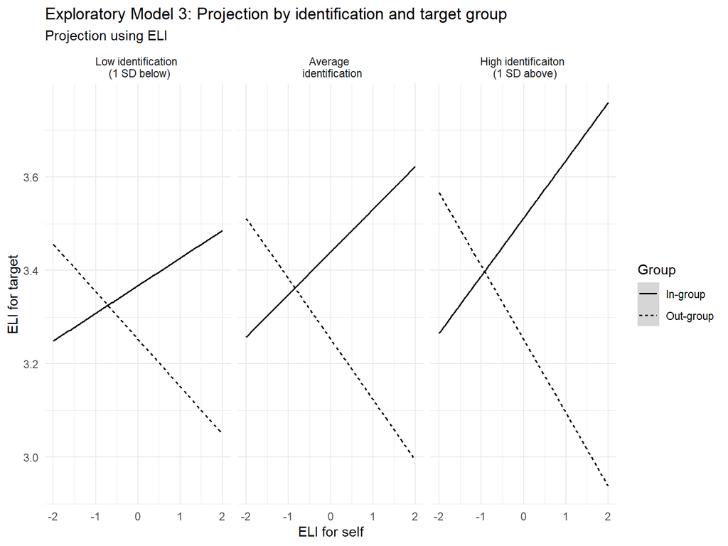

```r
knitr::opts_chunk$set(fig.width = 8, fig.height = 6)

ggplot(mod3EDnostereo_proj_ident_group_effects, aes(self_c,
                                     fit,
                                     group = group_cond,
                                     colour = group_cond)) +
  geom_smooth(method = "lm",
              size = .7,
              colour = "black",
              aes(linetype = group_cond)) +
  facet_grid(cols = vars(Identification)) +
  theme_minimal() +
  labs(title = "Exploratory Model 3: Projection by identification and target group",
       subtitle = "Projection using ELI",
       x = "ELI for self",
       y = "ELI for target",
       linetype = "Group")
```

```r
# ggpreview(width = 8, height = 6, units = "in")
```

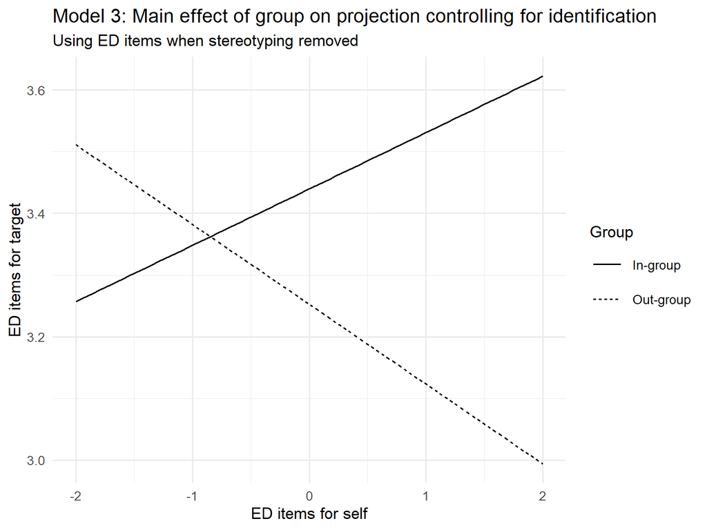

```r
mod3ED_nostereo_proj_group_plot <- get_groupME_proj_plot(model3ED_nostereo)

mod3ED_nostereo_proj_group_plot +
  labs(title = "Model 3: Main effect of group on projection controlling for identification",
       subtitle = "Using ED items when stereotyping removed",
         x = "ED items for self",
         y = "ED items for target",
         linetype = "Group")
```

Without stereotyping and only using ED, we see counter projection for out-group targets and regular projection for in-group targets.

## ED w/ stereo

```r
model3ED_stereo <- lmer(TargED ~ self_c*group_cond*identification_c*stereoED_c + (self_c|sub_id),
               data = dataED_mod3)

summary(model3ED_stereo)
```

```
## Linear mixed model fit by REML. t-tests use Satterthwaite's method [
## lmerModLmerTest]
## Formula: TargED ~ self_c * group_cond * identification_c * stereoED_c +
##     (self_c | sub_id)
##    Data: dataED_mod3
##
## REML criterion at convergence: 8377.5
##
## Scaled residuals:
##     Min      1Q  Median      3Q     Max
## -3.6487 -0.4874  0.0069  0.6795  3.8943
##
## Random effects:
##  Groups   Name        Variance Std.Dev. Corr
##  sub_id   (Intercept) 0.02806  0.1675
##           self_c      0.04063  0.2016   0.50
##  Residual             0.78946  0.8885
## Number of obs: 3069, groups:  sub_id, 616
##
## Fixed effects:
##                                                   Estimate  Std. Error
## (Intercept)                                       3.352250    0.018313
## self_c                                           -0.050015    0.015668
## group_cond1                                       0.042188    0.018313
## identification_c                                  0.020625    0.014349
## stereoED_c                                        0.475560    0.018093
## self_c:group_cond1                                0.058532    0.015668
## self_c:identification_c                          -0.001886    0.012224
## group_cond1:identification_c                      0.026582    0.014349
## self_c:stereoED_c                                 0.016879    0.012849
## group_cond1:stereoED_c                           -0.036162    0.018093
## identification_c:stereoED_c                      -0.001890    0.014557
## self_c:group_cond1:identification_c               0.000491    0.012224
## self_c:group_cond1:stereoED_c                     0.006456    0.012849
## self_c:identification_c:stereoED_c               -0.023185    0.010316
## group_cond1:identification_c:stereoED_c           0.013087    0.014557
## self_c:group_cond1:identification_c:stereoED_c   -0.021886    0.010316
##                                                         df t value
## (Intercept)                                     656.044893 183.052
## self_c                                          585.904562  -3.192
```

[output cut: 18 more lines]

```
## identification_c                                           0.151111
## stereoED_c                                     < 0.0000000000000002 ***
## self_c:group_cond1                                         0.000206 ***
## self_c:identification_c                                    0.877438
## group_cond1:identification_c                               0.064414 .
## self_c:stereoED_c                                          0.189058
## group_cond1:stereoED_c                                     0.045729 *
## identification_c:stereoED_c                                0.896716
## self_c:group_cond1:identification_c                        0.967972
## self_c:group_cond1:stereoED_c                              0.615403
## self_c:identification_c:stereoED_c                         0.024693 *
## group_cond1:identification_c:stereoED_c                    0.368698
## self_c:group_cond1:identification_c:stereoED_c             0.033965 *
## ---
## Signif. codes:  0 '***' 0.001 '**' 0.01 '*' 0.05 '.' 0.1 ' ' 1
```

```r
confint(model3ED_stereo)
```

```
##                                                       2.5 %        97.5 %
## .sig01                                          0.069397634  0.2272222700
## .sig02                                          0.138358772  0.9750298800
## .sig03                                          0.157383085  0.2377599886
## .sigma                                          0.860741039  0.9155911369
## (Intercept)                                     3.316452811  3.3879896853
## self_c                                         -0.080560856 -0.0193471735
## group_cond1                                     0.006402146  0.0779417131
## identification_c                               -0.007358640  0.0487257067
## stereoED_c                                      0.440178459  0.5111615853
## self_c:group_cond1                              0.027951435  0.0891343485
## self_c:identification_c                        -0.025769639  0.0219896787
## group_cond1:identification_c                   -0.001488784  0.0545839689
## self_c:stereoED_c                              -0.008386668  0.0422332969
## group_cond1:stereoED_c                         -0.071610065 -0.0008259497
## identification_c:stereoED_c                    -0.030303406  0.0267571778
## self_c:group_cond1:identification_c            -0.023374678  0.0243510900
## self_c:group_cond1:stereoED_c                  -0.018775032  0.0315164604
## self_c:identification_c:stereoED_c             -0.043349637 -0.0030137286
## group_cond1:identification_c:stereoED_c        -0.015385910  0.0415429061
## self_c:group_cond1:identification_c:stereoED_c -0.042021639 -0.0016985241
```

When including stereotyping, the main effect of group on projection is still significant, but the marginal interaction with identification disappears.

### Plots

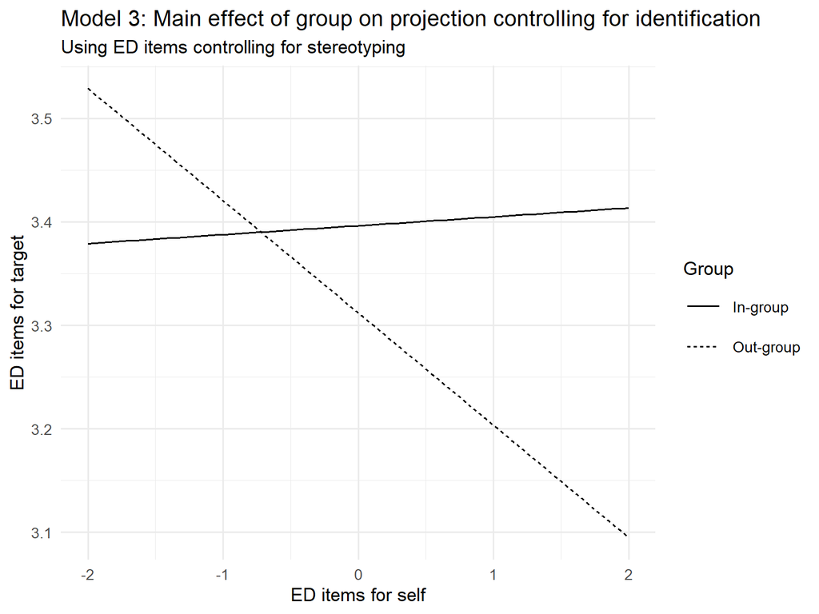

```r
mod3ED_stereo_proj_group_plot <- get_groupME_proj_plot(model3ED_stereo)

mod3ED_stereo_proj_group_plot +
  labs(title = "Model 3: Main effect of group on projection controlling for identification",
       subtitle = "Using ED items controlling for stereotyping",
         x = "ED items for self",
         y = "ED items for target",
         linetype = "Group")
```

```r
describe(dataED_mod3$stereoED_c)
```

```
##    vars    n mean   sd median trimmed  mad   min  max range  skew kurtosis   se
## X1    1 3069    0 1.02  -0.22    0.02 1.48 -2.22 1.78     4 -0.23    -0.12 0.02
```

```r
mod3EDstereo_3way_effects <- effect(term = "self_c:group_cond:stereoED_c",
                           xlevels = list(group_cond = c("In-group",
                                                         "Out-group"),
                                          stereoED_c = c(-1.04, 0, 1.04)),
                           mod = model3ED_stereo)

mod3EDstereo_3way_effects <- as.data.frame(mod3EDstereo_3way_effects)

mod3EDstereo_3way_effects %<>%
  mutate(Stereotyping = as.factor(stereoED_c),
         Stereotyping = dplyr::recode(Stereotyping,
                                      `-1.04` = "Low stereotyping \n (1 SD below)",
                                      `0` = "Average \n stereotyping",
                                      `1.04` = "High stereotyping \n (1 SD above"))
```

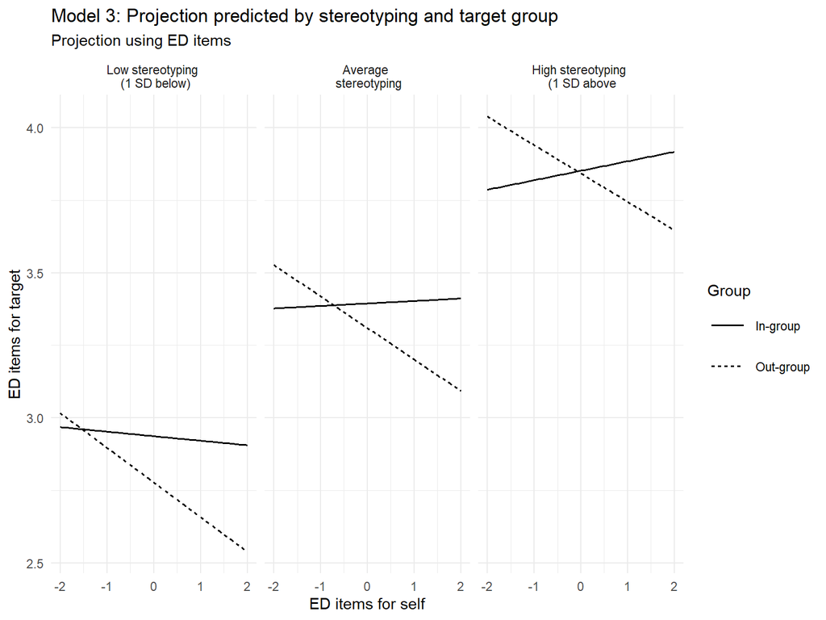

```r
ggplot(mod3EDstereo_3way_effects, aes(self_c,
                                      fit,
                                      group = group_cond,
                                      colour = group_cond)) +
  geom_smooth(method = "lm", se = FALSE, size = .7, colour = "black",
              aes(linetype = group_cond)) +
  facet_wrap(vars(Stereotyping)) +
  theme_minimal() +
  theme(legend.key.size = unit(1, "cm")) +
  labs(title = "Model 3: Projection predicted by stereotyping and target group",
       subtitle = "Projection using ED items",
       x = "ED items for self",
       y = "ED items for target",
       linetype = "Group")
```

Counter projection with out-group targets using ED remains the same regardless of stereotype use. People who use large amounts of stereotypes, project positively with their in-group. As stereotype use decreases, in-group projection decreases, ultimately becoming counter projection with low stereotype users.

```r
describe(dataED_mod3$stereoED_c)
```

```
##    vars    n mean   sd median trimmed  mad   min  max range  skew kurtosis   se
## X1    1 3069    0 1.02  -0.22    0.02 1.48 -2.22 1.78     4 -0.23    -0.12 0.02
```

```r
describe(dataED_mod3$identification_c)
```

```
##    vars    n mean   sd median trimmed  mad   min  max range  skew kurtosis   se
## X1    1 3069    0 1.27   0.61     0.1 1.48 -2.39 1.61     4 -0.43     -0.8 0.02
```

```r
mod3EDstereo_4way_effects <- effect(term = "self_c:group_cond:identification_c:stereoED_c",
                           xlevels = list(group_cond = c("In-group",
                                                         "Out-group"),
                                          stereoED_c = c(-1.04, 0, 1.04),
                                          identification_c = c(-1.28, 0 , 1.28)),
                           mod = model3ED_stereo)

mod3EDstereo_4way_effects <- as.data.frame(mod3EDstereo_4way_effects)

mod3EDstereo_4way_effects %<>%
  mutate(Stereotyping = as.factor(stereoED_c),
         Stereotyping = dplyr::recode(Stereotyping,
                                      `-1.04` = "Low stereotyping \n (1 SD below)",
                                      `0` = "Average \n stereotyping",
                                      `1.04` = "High stereotyping \n (1 SD above"),
         Identification = as.factor(identification_c),
         Identification = dplyr::recode(Identification,
                                        `-1.28` = "Low identification \n (1 SD below)",
                                        `0` = "Average \n identification",
                                        `1.28` = "High identification \n (1 SD above)"))
```

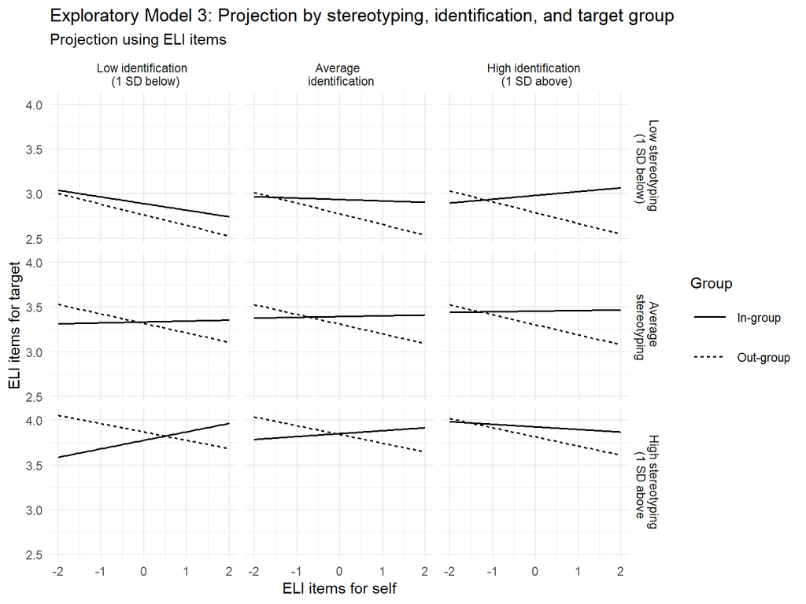

```r
knitr::opts_chunk$set(fig.width = 8, fig.height = 6)

ggplot(mod3EDstereo_4way_effects, aes(self_c,
                                      fit,
                                      group = group_cond,
                                      colour = group_cond)) +
  geom_smooth(method = "lm", se = FALSE, size = .7, colour = "black",
              aes(linetype = group_cond)) +
  facet_grid(vars(Stereotyping), vars(Identification)) +
  theme_minimal() +
  theme(legend.key.size = unit(1, "cm")) +
  labs(title = "Exploratory Model 3: Projection by stereotyping, identification, and target group",
       subtitle = "Projection using ELI items",
       x = "ELI items for self",
       y = "ELI items for target",
       linetype = "Group")
```

```r
# ggpreview(width = 8, height = 6, units = "in")
```

Counter projection with out-group targets is unaffected, the interaction is with in-group targets. Within low identifiers, as stereotype use increases, people go from counter projecting to projecting positively with their in-group. Average identifiers who are using little stereotypes do not counter project as much as low identifiers, though the slope only increases to become slightly positive as stereotype use increases among average identifiers. Among high identifiers, the pattern is opposite that of low identifiers: those who stereotype less project positively with their in-group, while, as stereotype use increases, positive projection disappears and becomes counter projection.

# Exp Model 4 from Pre-reg

## EFA

We decided to use only the ED data because we are assessing the impact of individual difference variables on counter projection, which we did not find with the BFI when controlled for stereotyping.

https://cran.r-project.org/web/packages/parameters/vignettes/efa_cfa.html

Missing data per individual difference variable:

```r
indivdiff_data <- clean_ptcheck %>%
  select(sub_id, TargED, selfED_c, stereoED_c, identification, identification_c,
         group_cond, lib, cons, contentiousness, threat, fundaMoral) %>%
  mutate_at(vars(lib), ~replace(., is.na(.), 99)) %>% #to remove NA's using filtering, making them 99's first, since filter wasn't letting me filter "NA"
  filter(lib != "99") %>%
  mutate(perceive_polar = abs(lib - cons),
         perceive_polar_c = perceive_polar - mean(perceive_polar, na.rm = TRUE),
         content_c = contentiousness - mean(contentiousness, na.rm = TRUE),
         threat_c = threat - mean(threat, na.rm = TRUE),
         fundaMoral_c = fundaMoral - mean(fundaMoral, na.rm = TRUE),
         self_c = selfED_c)#getting variable for perceived polar by subtracting perceived polarization for conservatives from liberals and getting teh absolute value of that diff

EFA <- indivdiff_data %>%
  select(sub_id, identification, threat, perceive_polar, fundaMoral, contentiousness) %>%
  unique() %>%
  select(-sub_id)

# Not too much missing data, I think we should be okay on power
sapply(EFA, function(x) sum(is.na(x)))
```

```
##  identification          threat  perceive_polar      fundaMoral contentiousness
##               2               5               2               2               2
```

### Exploratory N

```r
indivdiff_data %>%
  select(sub_id) %>%
  unique() %>%
  count()
```

```
##     n
## 1 600
```

### Can an EFA be run?

```r
# Check factor structure to see if there is enough correlation, etc. for factor analysis
check_factorstructure(EFA)
```

```
## # Is the data suitable for Factor Analysis?
##
##   - KMO: The Kaiser, Meyer, Olkin (KMO) measure of sampling adequacy suggests that data seems appropriate for factor analysis (KMO = 0.73).
##   - Sphericity: Bartlett's test of sphericity suggests that there is sufficient significant correlation in the data for factor analysis (Chisq(10) = 475.66, p < .001).
```

### What number of factors are advisable?

```r
factors_exp <- n_factors(EFA)
factors_exp
```

```
## # Method Agreement Procedure:
##
## The choice of 1 dimensions is supported by 12 (63.16%) methods out of 19 (Optimal coordinates, Acceleration factor, Parallel analysis, Kaiser criterion, SE Scree, R2, VSS complexity 1, Velicer's MAP, BIC, BIC (adjusted), CRMS, BIC).
```

```r
summary(factors_exp)
```

```
##   n_Factors n_Methods
## 1         1        12
## 2         2         3
## 3         4         3
## 4         5         1
```

The majority of tests suggest only 1 factor, followed by 2 or 4 latent factors. 2 latent factors may make more theoretical sense for so few variables, but we will look at all three options.

### 1 Factor EFA

```r
efa_1fac <- psych::fa(EFA, nfactors = 1) %>%
  model_parameters(sort = TRUE, threshold = "max")
efa_1fac
```

```
## # Rotated loadings from Factor Analysis (oblimin-rotation)
##
## Variable        | MR1  | Complexity | Uniqueness
## ------------------------------------------------
## fundaMoral      | 0.76 |    1.00    |    0.42
## threat          | 0.70 |    1.00    |    0.50
## identification  | 0.47 |    1.00    |    0.78
## contentiousness | 0.46 |    1.00    |    0.79
## perceive_polar  | 0.33 |    1.00    |    0.89
##
## The unique latent factor (oblimin rotation) accounted for 32.57% of the total variance of the original data.
```

### 2 Factor EFA

```r
efa_2fac <- psych::fa(EFA, nfactors = 2) %>%
  model_parameters(sort = TRUE, threshold = "max")
efa_2fac
```

```
## # Rotated loadings from Factor Analysis (oblimin-rotation)
##
## Variable        | MR1  | MR2  | Complexity | Uniqueness
## -------------------------------------------------------
## fundaMoral      | 0.81 |      |    1.00    |    0.37
## threat          | 0.61 |      |    1.06    |    0.56
## identification  | 0.53 |      |    1.04    |    0.74
## perceive_polar  | 0.32 |      |    1.02    |    0.89
## contentiousness |      | 1.00 |    1.00    |  4.16e-03
##
## The 2 latent factors (oblimin rotation) accounted for 48.70% of the total variance of the original data (MR1 = 28.27%, MR2 = 20.43%).
```

```r
efa_4fac <- psych::fa(EFA, nfactors = 4) %>%
  model_parameters(sort = TRUE, threshold = "max")
efa_4fac
```

```
## # Rotated loadings from Factor Analysis (oblimin-rotation)
##
## Variable        | MR1  | MR3  | MR4  | MR2  | Complexity | Uniqueness
## ---------------------------------------------------------------------
## fundaMoral      | 0.76 |      |      |      |    1.00    |    0.41
## contentiousness |      | 0.62 |      |      |    1.01    |    0.65
## threat          |      | 0.32 |      |      |    3.31    |    0.41
## identification  |      |      | 0.60 |      |    1.01    |    0.67
## perceive_polar  |      |      |      | 0.37 |    2.00    |    0.74
##
## The 4 latent factors (oblimin rotation) accounted for 42.39% of the total variance of the original data (MR1 = 17.10%, MR3 = 12.07%, MR4 = 9.51%, MR2 = 3.71%).
```

The EFA with 2 factors explains more of the total variance of the original data (49%). The 4 factor then explained the next highest amount of total variance (42%). Our singly factor latent variable EFA explained only 33% of the total variance.

It appears that the 2 factor structure is our best structure. This structure combines all factors but contentiousness into one factor, leaving us with factor 1: group beliefs and factor 2: contentiousness.

If we were to follow the 4 factor structure, only threat and contentiousness are combined into one factor, which I would label “aggression.” Fundamental Morals, Identification, and Perceived Polarization all fall into unique factors in this EFA.

## Alpha comparisons

### 1 factor

For comparison to other alphas:

```r
psych::alpha(EFA)
```

```
##
## Reliability analysis
## Call: psych::alpha(x = EFA)
##
##   raw_alpha std.alpha G6(smc) average_r S/N   ase mean   sd median_r
##        0.6      0.67    0.65      0.29 2.1 0.025  4.3 0.97     0.31
##
##  lower alpha upper     95% confidence boundaries
## 0.55 0.6 0.65
##
##  Reliability if an item is dropped:
##                 raw_alpha std.alpha G6(smc) average_r S/N alpha se  var.r med.r
## identification       0.56      0.64    0.60      0.31 1.8    0.029 0.0170  0.31
## threat               0.50      0.57    0.52      0.25 1.3    0.031 0.0095  0.24
## perceive_polar       0.69      0.69    0.64      0.35 2.2    0.020 0.0131  0.37
## fundaMoral           0.47      0.55    0.50      0.23 1.2    0.033 0.0108  0.17
## contentiousness      0.56      0.65    0.60      0.31 1.8    0.029 0.0183  0.33
##
##  Item statistics
##                   n raw.r std.r r.cor r.drop mean  sd
## identification  598  0.57  0.62  0.46   0.35  3.4 1.3
## threat          595  0.68  0.74  0.67   0.47  3.4 1.4
## perceive_polar  598  0.71  0.55  0.34   0.28  6.6 2.4
## fundaMoral      598  0.71  0.77  0.71   0.56  4.0 1.2
## contentiousness 598  0.55  0.62  0.46   0.36  4.1 1.1
```

This alpha is .6. The latent factors for our 2 factor and 4 factor would need to be better.

### 2 factor combined factor

```r
group_beliefs <- EFA %>%
  select(c(identification, perceive_polar, fundaMoral, threat))

psych::alpha(group_beliefs)
```

```
##
## Reliability analysis
## Call: psych::alpha(x = group_beliefs)
##
##   raw_alpha std.alpha G6(smc) average_r S/N   ase mean  sd median_r
##       0.56      0.65     0.6      0.31 1.8 0.029  4.3 1.1     0.33
##
##  lower alpha upper     95% confidence boundaries
## 0.5 0.56 0.62
##
##  Reliability if an item is dropped:
##                raw_alpha std.alpha G6(smc) average_r  S/N alpha se  var.r med.r
## identification      0.50      0.60    0.53      0.33 1.47    0.034 0.0301  0.30
## perceive_polar      0.68      0.68    0.60      0.42 2.14    0.023 0.0077  0.38
## fundaMoral          0.39      0.47    0.38      0.23 0.88    0.040 0.0120  0.17
## threat              0.45      0.54    0.45      0.28 1.15    0.035 0.0127  0.30
##
##  Item statistics
##                  n raw.r std.r r.cor r.drop mean  sd
## identification 598  0.60  0.68  0.49   0.35  3.4 1.3
## perceive_polar 598  0.75  0.58  0.33   0.26  6.6 2.4
## fundaMoral     598  0.72  0.79  0.71   0.54  4.0 1.2
## threat         595  0.66  0.73  0.62   0.41  3.4 1.4
```

### 4 factor combined factor

```r
aggression <- EFA %>%
  select(c(threat, contentiousness))

psych::alpha(aggression)
```

```
##
## Reliability analysis
## Call: psych::alpha(x = aggression)
##
##   raw_alpha std.alpha G6(smc) average_r S/N   ase mean sd median_r
##       0.54      0.55    0.38      0.38 1.2 0.036  3.8  1     0.38
##
##  lower alpha upper     95% confidence boundaries
## 0.47 0.54 0.61
##
##  Reliability if an item is dropped:
##                 raw_alpha std.alpha G6(smc) average_r  S/N alpha se var.r med.r
## threat               0.48      0.38    0.14      0.38 0.61       NA     0  0.38
## contentiousness      0.30      0.38    0.14      0.38 0.61       NA     0  0.38
##
##  Item statistics
##                   n raw.r std.r r.cor r.drop mean  sd
## threat          595  0.87  0.83  0.51   0.38  3.4 1.4
## contentiousness 598  0.79  0.83  0.51   0.38  4.1 1.1
##
## Non missing response frequency for each item
##                    1    2    3    4    5 miss
## threat          0.13 0.14 0.17 0.26 0.30 0.01
## contentiousness 0.03 0.06 0.18 0.24 0.49 0.00
```

We did state that we would combined moderators that were correlated greater than .7 if the EFA and reliability plan failed. We will look into this next.

## Correlation matrix

```r
cor(EFA, method = "pearson", use = "complete.obs")
```

```
##                 identification    threat perceive_polar fundaMoral
## identification       1.0000000 0.3503860      0.1559566  0.3770519
## threat               0.3503860 1.0000000      0.1763310  0.5188116
## perceive_polar       0.1559566 0.1763310      1.0000000  0.3050746
## fundaMoral           0.3770519 0.5188116      0.3050746  1.0000000
## contentiousness      0.1616872 0.3849546      0.1692392  0.3396336
##                 contentiousness
## identification        0.1616872
## threat                0.3849546
## perceive_polar        0.1692392
## fundaMoral            0.3396336
## contentiousness       1.0000000
```

None of the variables are correlation over .7 (actually .52 is the highest), so we will use them all individually.

## Exploratory results

We only used everyday likes because it is the scale we consistently saw counter projection with out-group targets. As we are specifically interested in counter projection with out-group targets, which stereotyping did not impact with everyday likes, we ran these models without stereotyping.

```r
indivdiff_data <- indivdiff_data %>%
  select(-perceive_polar, - contentiousness, -selfED_c,
         -lib, -cons, -fundaMoral, -threat, -identification) %>%
  na.omit()

contrasts(indivdiff_data$group_cond) <- contr.sum(2)
contrasts(indivdiff_data$group_cond)
```

```
##           [,1]
## In-group     1
## Out-group   -1
```

### Perceived polar model

```r
model4_polar <- lmer(TargED ~ group_cond*self_c*perceive_polar_c  +
                        + (self_c|sub_id),
               data = indivdiff_data)

summary(model4_polar)
```

```
## Linear mixed model fit by REML. t-tests use Satterthwaite's method [
## lmerModLmerTest]
## Formula: TargED ~ group_cond * self_c * perceive_polar_c + +(self_c |
##     sub_id)
##    Data: indivdiff_data
##
## REML criterion at convergence: 134712.4
##
## Scaled residuals:
##     Min      1Q  Median      3Q     Max
## -3.8238 -0.5167  0.0125  0.5857  3.3841
##
## Random effects:
##  Groups   Name        Variance Std.Dev. Corr
##  sub_id   (Intercept) 0.2929   0.5412
##           self_c      0.2684   0.5181   -0.04
##  Residual             0.6098   0.7809
## Number of obs: 55540, groups:  sub_id, 588
##
## Fixed effects:
##                                       Estimate Std. Error         df t value
## (Intercept)                           3.352853   0.022704 560.870711 147.676
## group_cond1                           0.097208   0.022704 560.870711   4.282
## self_c                               -0.013745   0.021697 568.351428  -0.633
## perceive_polar_c                      0.007917   0.009375 561.301994   0.844
## group_cond1:self_c                    0.076793   0.021697 568.351428   3.539
## group_cond1:perceive_polar_c          0.014726   0.009375 561.301994   1.571
## self_c:perceive_polar_c              -0.018934   0.008971 570.756237  -2.111
## group_cond1:self_c:perceive_polar_c   0.021130   0.008971 570.756237   2.355
##                                                 Pr(>|t|)
## (Intercept)                         < 0.0000000000000002 ***
## group_cond1                                    0.0000218 ***
## self_c                                          0.526670
## perceive_polar_c                                0.398759
## group_cond1:self_c                              0.000434 ***
## group_cond1:perceive_polar_c                    0.116784
## self_c:perceive_polar_c                         0.035243 *
## group_cond1:self_c:perceive_polar_c             0.018843 *
## ---
## Signif. codes:  0 '***' 0.001 '**' 0.01 '*' 0.05 '.' 0.1 ' ' 1
##
## Correlation of Fixed Effects:
##             (Intr) grp_c1 self_c prcv__ gr_1:_ g_1:__ sl_:__
## group_cond1 -0.021
## self_c      -0.046  0.002
## percv_plr_c -0.016  0.031  0.000
## grp_cnd1:s_  0.002 -0.046 -0.020 -0.004
## grp_cnd1:__  0.031 -0.016 -0.004 -0.054  0.000
## slf_c:prc__  0.000 -0.004 -0.018 -0.047  0.034  0.005
## grp_c1:_:__ -0.004  0.000  0.034  0.005 -0.018 -0.047 -0.053
```

```r
confint(model4_polar)
```

```
##                                            2.5 %       97.5 %
## .sig01                               0.508170233  0.573221915
## .sig02                              -0.127487529  0.042798650
## .sig03                               0.486763962  0.548386481
## .sigma                               0.776294786  0.785584865
## (Intercept)                          3.308435927  3.397260481
## group_cond1                          0.052792376  0.141615770
## self_c                              -0.056176782  0.028709874
## perceive_polar_c                    -0.010424183  0.026251898
## group_cond1:self_c                   0.034348525  0.119235680
## group_cond1:perceive_polar_c        -0.003611293  0.033065428
## self_c:perceive_polar_c             -0.036485439 -0.001388287
## group_cond1:self_c:perceive_polar_c  0.003574535  0.038672822
```

#### Main effect

```r
describe(indivdiff_data$perceive_polar_c)
```

```
##    vars     n mean   sd median trimmed  mad   min  max range  skew kurtosis
## X1    1 55540 0.04 2.42   0.44    0.25 2.97 -6.56 3.44    10 -0.77     0.21
##      se
## X1 0.01
```

```r
mod4_polar_ME_effects <- effect(term = "self_c:perceive_polar_c",
                           xlevels = list(perceive_polar_c = c(-2.42, 0, 2.42)),
                           mod = model4_polar)

mod4_polar_ME_effects <- as.data.frame(mod4_polar_ME_effects)

mod4_polar_ME_effects %<>%
  mutate(Polarization = as.factor(perceive_polar_c),
         Polarization = dplyr::recode(Polarization,
                                         `-2.42` = "Low (1 SD below)",
                                         `0` = "Average",
                                         `2.42` = "High (1 SD above)"))
```

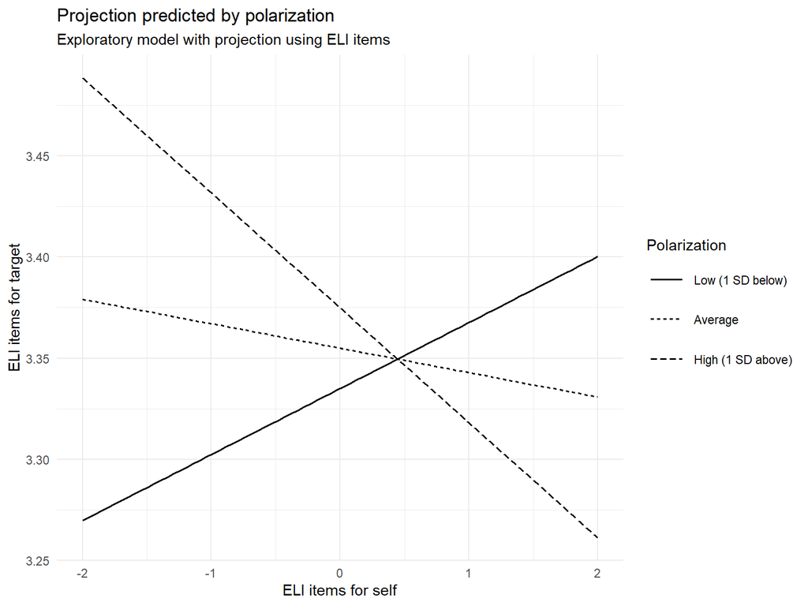

```r
knitr::opts_chunk$set(fig.width = 8, fig.height = 6)

ggplot(mod4_polar_ME_effects, aes(self_c,
                                      fit,
                                      group = Polarization,
                                      colour = Polarization)) +
  geom_smooth(method = "lm", se = FALSE, size = .7, colour = "black",
              aes(linetype = Polarization)) +
  theme_minimal() +
  theme(legend.key.size = unit(1, "cm")) +
  labs(title = "Projection predicted by polarization",
       subtitle = "Exploratory model with projection using ELI items",
       x = "ELI items for self",
       y = "ELI items for target",
       linetype = "Polarization")
```

```r
# ggpreview(width = 8, height = 6, units = "in")
```

#### Group x Polarization Int Plot

```r
describe(indivdiff_data$perceive_polar_c)
```

```
##    vars     n mean   sd median trimmed  mad   min  max range  skew kurtosis
## X1    1 55540 0.04 2.42   0.44    0.25 2.97 -6.56 3.44    10 -0.77     0.21
##      se
## X1 0.01
```

```r
mod4_polar_effects <- effect(term = "group_cond:self_c:perceive_polar_c",
                           xlevels = list(perceive_polar_c = c(-2.42, 0, 2.42),
                                          group_cond = c("In-group", "Out-group")),
                           mod = model4_polar)

mod4_polar_effects <- as.data.frame(mod4_polar_effects)

mod4_polar_effects %<>%
  mutate(Polarization = as.factor(perceive_polar_c),
         Polarization = dplyr::recode(Polarization,
                                         `-2.42` = "Low polarization \n (1 SD below)",
                                         `0` = "Average \n polarization",
                                         `2.42` = "High polarization \n (1 SD above)"))
```

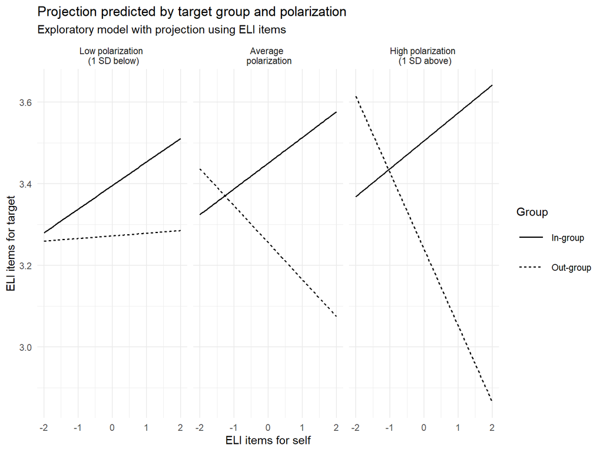

```r
knitr::opts_chunk$set(fig.width = 8, fig.height = 6)

ggplot(mod4_polar_effects, aes(self_c,
                                      fit,
                                      group = group_cond,
                                      colour = group_cond)) +
  geom_smooth(method = "lm", se = FALSE, size = .7, colour = "black",
              aes(linetype = group_cond)) +
  facet_wrap(vars(Polarization)) +
  theme_minimal() +
  theme(legend.key.size = unit(1, "cm")) +
  labs(title = "Projection predicted by target group and polarization",
       subtitle = "Exploratory model with projection using ELI items",
       x = "ELI items for self",
       y = "ELI items for target",
       linetype = "Group")
```

```r
# ggpreview(width = 8, height = 6, units = "in")
```

At low polarization, we see slight positive projection with the out-group. However, once people regard polarization as average, we see steep counter projection that increases with high polarization. In-group projection remains similar across polarization, with the only change being an increase in intercept. This effect is marginal with stereotyping included in the model.

### Threat model

```r
model4_threat <- lmer(TargED ~ group_cond*self_c*threat_c +
                        + (self_c|sub_id),
               data = indivdiff_data)

summary(model4_threat)
```

```
## Linear mixed model fit by REML. t-tests use Satterthwaite's method [
## lmerModLmerTest]
## Formula: TargED ~ group_cond * self_c * threat_c + +(self_c | sub_id)
##    Data: indivdiff_data
##
## REML criterion at convergence: 134717.1
##
## Scaled residuals:
##     Min      1Q  Median      3Q     Max
## -3.8265 -0.5192  0.0123  0.5848  3.3823
##
## Random effects:
##  Groups   Name        Variance Std.Dev. Corr
##  sub_id   (Intercept) 0.2936   0.5419
##           self_c      0.2723   0.5218   -0.04
##  Residual             0.6098   0.7809
## Number of obs: 55540, groups:  sub_id, 588
##
## Fixed effects:
##                               Estimate Std. Error         df t value
## (Intercept)                   3.352427   0.022720 562.013424 147.557
## group_cond1                   0.096746   0.022720 562.013424   4.258
## self_c                       -0.015933   0.021838 567.809922  -0.730
## threat_c                     -0.021586   0.016368 561.597271  -1.319
## group_cond1:self_c            0.078954   0.021838 567.809922   3.615
## group_cond1:threat_c          0.014054   0.016368 561.597271   0.859
## self_c:threat_c              -0.014868   0.015725 566.981040  -0.946
## group_cond1:self_c:threat_c   0.009353   0.015725 566.981040   0.595
##                                         Pr(>|t|)
## (Intercept)                 < 0.0000000000000002 ***
## group_cond1                            0.0000241 ***
## self_c                                  0.465917
## threat_c                                0.187791
## group_cond1:self_c                      0.000326 ***
## group_cond1:threat_c                    0.390906
## self_c:threat_c                         0.344802
## group_cond1:self_c:threat_c             0.552219
## ---
## Signif. codes:  0 '***' 0.001 '**' 0.01 '*' 0.05 '.' 0.1 ' ' 1
##
## Correlation of Fixed Effects:
##             (Intr) grp_c1 self_c thrt_c grp_cnd1:s_ grp_cnd1:t_ slf_:_
## group_cond1 -0.021
## self_c      -0.046  0.002
## threat_c    -0.003  0.012  0.001
## grp_cnd1:s_  0.002 -0.046 -0.019 -0.003
## grp_cnd1:t_  0.012 -0.003 -0.003 -0.037  0.001
## slf_c:thrt_  0.001 -0.003 -0.004 -0.046  0.013       0.004
## grp_cn1:_:_ -0.003  0.001  0.013  0.004 -0.004      -0.046      -0.037
```

```r
confint(model4_threat)
```

```
##                                   2.5 %     97.5 %
## .sig01                       0.50883796 0.57388753
## .sig02                      -0.12742519 0.04283586
## .sig03                       0.49031495 0.55237720
## .sigma                       0.77629173 0.78558172
## (Intercept)                  3.30797931 3.39686480
## group_cond1                  0.05230045 0.14118481
## self_c                      -0.05863852 0.02679644
## threat_c                    -0.05359929 0.01043996
## group_cond1:self_c           0.03623575 0.12167203
## group_cond1:threat_c        -0.01796709 0.04606979
## self_c:threat_c             -0.04564240 0.01588103
## group_cond1:self_c:threat_c -0.02140464 0.04011653
```

Threat does not moderate counter projection with everyday likes.

### Contentiousness model

```r
model4_content <- lmer(TargED ~ group_cond*self_c*content_c  +
                        + (self_c|sub_id),
               data = indivdiff_data)

summary(model4_content)
```

```
## Linear mixed model fit by REML. t-tests use Satterthwaite's method [
## lmerModLmerTest]
## Formula: TargED ~ group_cond * self_c * content_c + +(self_c | sub_id)
##    Data: indivdiff_data
##
## REML criterion at convergence: 134717.9
##
## Scaled residuals:
##     Min      1Q  Median      3Q     Max
## -3.8260 -0.5187  0.0122  0.5848  3.3850
##
## Random effects:
##  Groups   Name        Variance Std.Dev. Corr
##  sub_id   (Intercept) 0.2943   0.5425
##           self_c      0.2728   0.5223   -0.04
##  Residual             0.6098   0.7809
## Number of obs: 55540, groups:  sub_id, 588
##
## Fixed effects:
##                                Estimate Std. Error         df t value
## (Intercept)                    3.352035   0.022752 561.201115 147.332
## group_cond1                    0.096512   0.022752 561.201115   4.242
## self_c                        -0.016350   0.021862 568.047433  -0.748
## content_c                      0.018966   0.020917 560.346891   0.907
## group_cond1:self_c             0.078981   0.021862 568.047433   3.613
## group_cond1:content_c          0.002528   0.020917 560.346891   0.121
## self_c:content_c               0.005213   0.020090 566.416518   0.259
## group_cond1:self_c:content_c   0.006952   0.020090 566.416518   0.346
##                                          Pr(>|t|)
## (Intercept)                  < 0.0000000000000002 ***
## group_cond1                             0.0000259 ***
## self_c                                    0.45484
## content_c                                 0.36493
## group_cond1:self_c                        0.00033 ***
## group_cond1:content_c                     0.90384
## self_c:content_c                          0.79536
## group_cond1:self_c:content_c              0.72944
## ---
## Signif. codes:  0 '***' 0.001 '**' 0.01 '*' 0.05 '.' 0.1 ' ' 1
##
## Correlation of Fixed Effects:
##             (Intr) grp_c1 self_c cntnt_ grp_cnd1:s_ grp_cnd1:c_ slf_:_
## group_cond1 -0.020
## self_c      -0.043  0.002
## content_c    0.000 -0.027 -0.002
## grp_cnd1:s_  0.002 -0.043 -0.019  0.001
## grp_cnd1:c_ -0.027  0.000  0.001 -0.051 -0.002
## slf_c:cntn_ -0.002  0.001 -0.001 -0.040 -0.025       0.003
## grp_cn1:_:_  0.001 -0.002 -0.025  0.003 -0.001      -0.040      -0.048
```

```r
confint(model4_content)
```

```
##                                    2.5 %     97.5 %
## .sig01                        0.50940551 0.57458133
## .sig02                       -0.12451789 0.04576331
## .sig03                        0.49075953 0.55285951
## .sigma                        0.77629334 0.78558337
## (Intercept)                   3.30752592 3.39653570
## group_cond1                   0.05200372 0.14101290
## self_c                       -0.05910304 0.02642700
## content_c                    -0.02195029 0.05988086
## group_cond1:self_c            0.03621494 0.12174564
## group_cond1:content_c        -0.03839116 0.04343945
## self_c:content_c             -0.03409263 0.04450341
## group_cond1:self_c:content_c -0.03234919 0.04624591
```

Contentiousness does not moderate counter projection with everyday likes.

### Fundamental moral model

```r
model4_fundmoral <- lmer(TargED ~ group_cond*self_c*fundaMoral_c  +
                        + (self_c|sub_id),
               data = indivdiff_data)

summary(model4_fundmoral)
```

```
## Linear mixed model fit by REML. t-tests use Satterthwaite's method [
## lmerModLmerTest]
## Formula: TargED ~ group_cond * self_c * fundaMoral_c + +(self_c | sub_id)
##    Data: indivdiff_data
##
## REML criterion at convergence: 134710.3
##
## Scaled residuals:
##     Min      1Q  Median      3Q     Max
## -3.8260 -0.5191  0.0116  0.5854  3.3838
##
## Random effects:
##  Groups   Name        Variance Std.Dev. Corr
##  sub_id   (Intercept) 0.2919   0.5402
##           self_c      0.2711   0.5207   -0.04
##  Residual             0.6098   0.7809
## Number of obs: 55540, groups:  sub_id, 588
##
## Fixed effects:
##                                  Estimate Std. Error        df t value
## (Intercept)                       3.35463    0.02274 560.81977 147.544
## group_cond1                       0.09976    0.02274 560.81977   4.388
## self_c                           -0.01323    0.02188 568.10693  -0.605
## fundaMoral_c                      0.03223    0.01959 559.33120   1.646
## group_cond1:self_c                0.07579    0.02188 568.10693   3.464
## group_cond1:fundaMoral_c          0.02945    0.01959 559.33120   1.503
## self_c:fundaMoral_c              -0.02807    0.01886 567.90960  -1.488
## group_cond1:self_c:fundaMoral_c   0.02507    0.01886 567.90960   1.329
##                                             Pr(>|t|)
## (Intercept)                     < 0.0000000000000002 ***
## group_cond1                                0.0000137 ***
## self_c                                      0.545635
## fundaMoral_c                                0.100419
## group_cond1:self_c                          0.000572 ***
## group_cond1:fundaMoral_c                    0.133353
## self_c:fundaMoral_c                         0.137181
## group_cond1:self_c:fundaMoral_c             0.184306
## ---
## Signif. codes:  0 '***' 0.001 '**' 0.01 '*' 0.05 '.' 0.1 ' ' 1
##
## Correlation of Fixed Effects:
##             (Intr) grp_c1 self_c fndMr_ gr_1:_ g_1:M_ sl_:M_
## group_cond1 -0.023
## self_c      -0.042  0.001
## fundaMorl_c -0.022  0.086 -0.002
## grp_cnd1:s_  0.001 -0.042 -0.022 -0.004
## grp_cnd1:M_  0.086 -0.022 -0.004 -0.116 -0.002
## slf_c:fndM_ -0.002 -0.004 -0.024 -0.039  0.089  0.005
## grp_c1:_:M_ -0.004 -0.002  0.089  0.005 -0.024 -0.039 -0.116
```

```r
confint(model4_fundmoral)
```

```
##                                        2.5 %     97.5 %
## .sig01                           0.507228769 0.57216364
## .sig02                          -0.123163626 0.04718655
## .sig03                           0.489252895 0.55117780
## .sigma                           0.776294319 0.78558440
## (Intercept)                      3.310151185 3.39910101
## group_cond1                      0.055276843 0.14422653
## self_c                          -0.056015071 0.02957810
## fundaMoral_c                    -0.006088172 0.07054735
## group_cond1:self_c               0.032991486 0.11858566
## group_cond1:fundaMoral_c        -0.008871639 0.06776436
## self_c:fundaMoral_c             -0.064959334 0.00882184
## group_cond1:self_c:fundaMoral_c -0.011833210 0.06194975
```

Fundamental moral beliefs does not moderate counter projection with everyday likes.

# Other Exploratory Analyses

## Exp results w/ voting opinion

### ED + BFI Results

```r
mod_opin_EDBFI <- lmer(Targ ~ group_cond*self_c*opin_pol_combined +
                        + (self_c|sub_id),
               data = EDBFI_mod2)

summary(mod_opin_EDBFI)
```

```
## Linear mixed model fit by REML. t-tests use Satterthwaite's method [
## lmerModLmerTest]
## Formula: Targ ~ group_cond * self_c * opin_pol_combined + +(self_c | sub_id)
##    Data: EDBFI_mod2
##
## REML criterion at convergence: 86121.9
##
## Scaled residuals:
##     Min      1Q  Median      3Q     Max
## -3.6768 -0.6086  0.0556  0.6757  3.5148
##
## Random effects:
##  Groups   Name        Variance Std.Dev. Corr
##  sub_id   (Intercept) 0.10640  0.3262
##           self_c      0.06834  0.2614   0.36
##  Residual             1.00646  1.0032
## Number of obs: 29514, groups:  sub_id, 618
##
## Fixed effects:
##                                                 Estimate Std. Error        df
## (Intercept)                                      3.37748    0.03289 613.64377
## group_cond1                                      0.09497    0.03289 613.64377
## self_c                                           0.12267    0.02649 620.23171
## opin_pol_combinedAnti Trump                     -0.05305    0.03660 613.61157
## group_cond1:self_c                               0.14127    0.02649 620.23171
## group_cond1:opin_pol_combinedAnti Trump          0.16367    0.03660 613.61157
## self_c:opin_pol_combinedAnti Trump              -0.07345    0.02948 619.84375
## group_cond1:self_c:opin_pol_combinedAnti Trump  -0.01453    0.02948 619.84375
##                                                t value             Pr(>|t|)
## (Intercept)                                    102.685 < 0.0000000000000002 ***
## group_cond1                                      2.887              0.00402 **
## self_c                                           4.630          0.000004450 ***
## opin_pol_combinedAnti Trump                     -1.449              0.14774
## group_cond1:self_c                               5.332          0.000000136 ***
## group_cond1:opin_pol_combinedAnti Trump          4.472          0.000009253 ***
## self_c:opin_pol_combinedAnti Trump              -2.491              0.01298 *
## group_cond1:self_c:opin_pol_combinedAnti Trump  -0.493              0.62226
## ---
## Signif. codes:  0 '***' 0.001 '**' 0.01 '*' 0.05 '.' 0.1 ' ' 1
##
## Correlation of Fixed Effects:
##             (Intr) grp_c1 self_c op__AT gr_1:_ g_1:__T s_:__T
## group_cond1 -0.009
## self_c       0.296  0.000
## opn_pl_cmAT -0.899  0.008 -0.266
## grp_cnd1:s_  0.000  0.296 -0.009  0.000
## grp_c1:__AT  0.008 -0.899  0.000 -0.008 -0.266
## slf_c:p__AT -0.266  0.000 -0.899  0.298  0.008  0.000
## gr_1:_:__AT  0.000 -0.266  0.008  0.000 -0.899  0.298  -0.008
```

#### Plot ME opinion

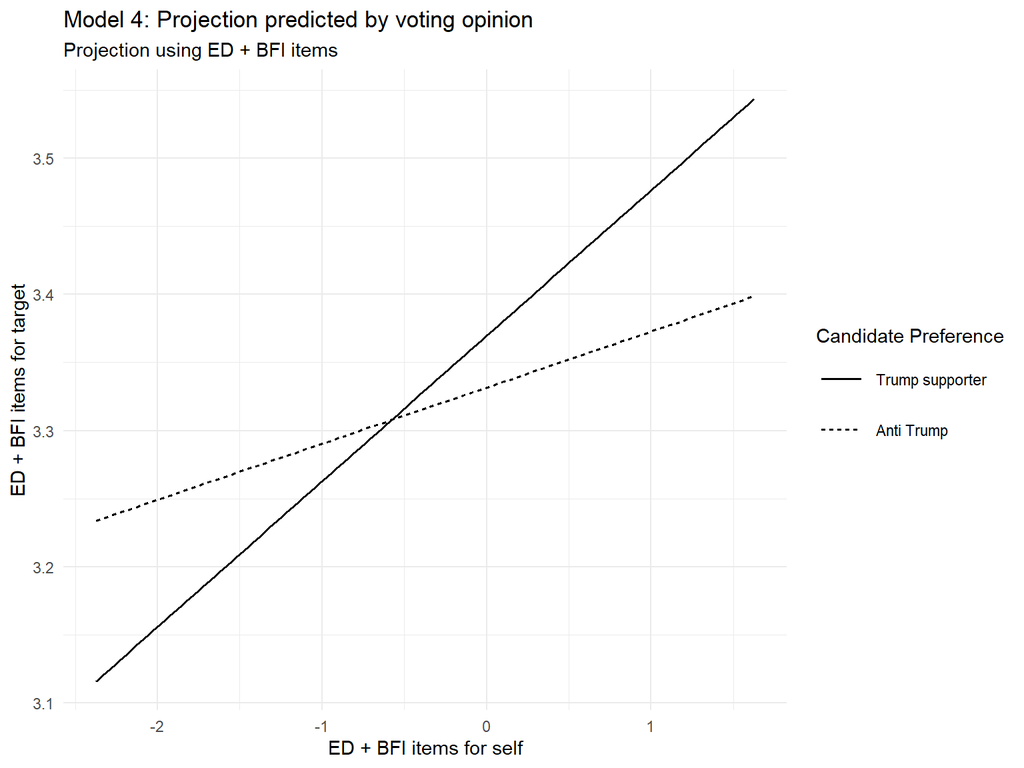

```r
ggplot(EDBFI_mod2, aes(self_c,
                       Targ,
                       group = opin_pol_combined,
                       colour = opin_pol_combined)) +
  geom_smooth(method = "lm", se = FALSE, size = .7, colour = "black",
              aes(linetype = opin_pol_combined)) +
  theme_minimal() +
  theme(legend.key.size = unit(1, "cm")) +
  labs(title = "Model 4: Projection predicted by voting opinion",
       subtitle = "Projection using ED + BFI items",
       x = "ED + BFI items for self",
       y = "ED + BFI items for target",
       linetype = "Candidate Preference")
```

### ED Only

```r
#removing na's for particular analysis for ED analysis
mod_opin_ed_data <- clean_ptcheck %>%
  select(sub_id, TargED, group_cond, selfED_c, opin_pol_combined) %>%
  na.omit()

mod_opin_ED <- lmer(TargED ~ group_cond*selfED_c*opin_pol_combined +
                        + (selfED_c|sub_id),
               data = mod_opin_ed_data)

summary(mod_opin_ED)
```

```
## Linear mixed model fit by REML. t-tests use Satterthwaite's method [
## lmerModLmerTest]
## Formula: TargED ~ group_cond * selfED_c * opin_pol_combined + +(selfED_c |
##     sub_id)
##    Data: mod_opin_ed_data
##
## REML criterion at convergence: 278283
##
## Scaled residuals:
##     Min      1Q  Median      3Q     Max
## -3.8589 -0.5192  0.0060  0.5809  3.4231
##
## Random effects:
##  Groups   Name        Variance Std.Dev. Corr
##  sub_id   (Intercept) 0.3106   0.5573
##           selfED_c    0.2855   0.5343   -0.06
##  Residual             0.6021   0.7759
## Number of obs: 116960, groups:  sub_id, 618
##
## Fixed effects:
##                                                           Estimate Std. Error
## (Intercept)                                                3.36544    0.07254
## group_condOut-group                                        0.04850    0.10318
## selfED_c                                                   0.18727    0.06943
## opin_pol_combinedAnti Trump                                0.10806    0.08075
## group_condOut-group:selfED_c                              -0.27368    0.09874
## group_condOut-group:opin_pol_combinedAnti Trump           -0.31027    0.11478
## selfED_c:opin_pol_combinedAnti Trump                      -0.16151    0.07731
## group_condOut-group:selfED_c:opin_pol_combinedAnti Trump   0.13379    0.10987
##                                                                 df t value
## (Intercept)                                              598.80931  46.392
## group_condOut-group                                      602.08596   0.470
## selfED_c                                                 603.48530   2.697
## opin_pol_combinedAnti Trump                              598.68882   1.338
## group_condOut-group:selfED_c                             606.75822  -2.772
## group_condOut-group:opin_pol_combinedAnti Trump          601.15260  -2.703
## selfED_c:opin_pol_combinedAnti Trump                     603.80440  -2.089
## group_condOut-group:selfED_c:opin_pol_combinedAnti Trump 606.16410   1.218
##                                                                      Pr(>|t|)
## (Intercept)                                              < 0.0000000000000002
```

[output cut: 13 more lines]

```
## group_condOut-group:opin_pol_combinedAnti Trump          **
## selfED_c:opin_pol_combinedAnti Trump                     *
## group_condOut-group:selfED_c:opin_pol_combinedAnti Trump
## ---
## Signif. codes:  0 '***' 0.001 '**' 0.01 '*' 0.05 '.' 0.1 ' ' 1
##
## Correlation of Fixed Effects:
##             (Intr) grp_O- slfED_ op__AT g_O-:E g_O-:_T sED_:T
## grp_cndOt-g -0.703
## selfED_c    -0.062  0.043
## opn_pl_cmAT -0.898  0.632  0.055
## grp_cO-:ED_  0.043 -0.062 -0.703 -0.039
## grp_O-:__AT  0.632 -0.899 -0.039 -0.704  0.056
## slfED_:__AT  0.055 -0.039 -0.898 -0.061  0.631  0.043
## g_O-:ED_:_T -0.039  0.056  0.632  0.043 -0.899 -0.062  -0.704
```

```r
confint(mod_opin_ED)
```

```
##                                                                2.5 %
## .sig01                                                    0.52496844
## .sig02                                                   -0.13854007
## .sig03                                                    0.50349915
## .sigma                                                    0.77279954
## (Intercept)                                               3.22350006
## group_condOut-group                                      -0.15333857
## selfED_c                                                  0.05144097
## opin_pol_combinedAnti Trump                              -0.04990559
## group_condOut-group:selfED_c                             -0.46684635
## group_condOut-group:opin_pol_combinedAnti Trump          -0.53483174
## selfED_c:opin_pol_combinedAnti Trump                     -0.31278223
## group_condOut-group:selfED_c:opin_pol_combinedAnti Trump -0.08118919
##                                                               97.5 %
## .sig01                                                    0.58879889
## .sig02                                                    0.02323001
## .sig03                                                    0.56427581
## .sigma                                                    0.77912306
## (Intercept)                                               3.50735018
## group_condOut-group                                       0.25037993
## selfED_c                                                  0.32312072
## opin_pol_combinedAnti Trump                               0.26604846
## group_condOut-group:selfED_c                             -0.08047025
## group_condOut-group:opin_pol_combinedAnti Trump          -0.08571561
## selfED_c:opin_pol_combinedAnti Trump                     -0.01026019
## group_condOut-group:selfED_c:opin_pol_combinedAnti Trump  0.34873387
```

#### Plot ME Opinion

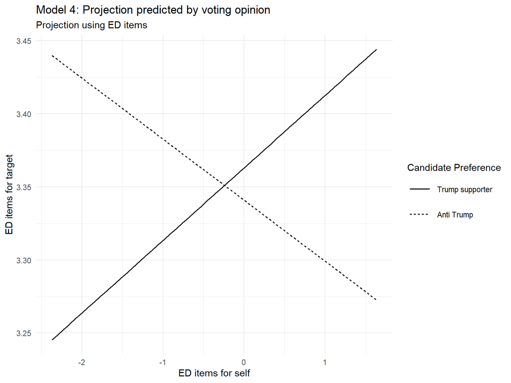

```r
ggplot(mod_opin_ed_data, aes(selfED_c,
                       TargED,
                       group = opin_pol_combined,
                       colour = opin_pol_combined)) +
  geom_smooth(method = "lm", se = FALSE, size = .7, colour = "black",
              aes(linetype = opin_pol_combined)) +
  theme_minimal() +
  theme(legend.key.size = unit(1, "cm")) +
  labs(title = "Model 4: Projection predicted by voting opinion",
       subtitle = "Projection using ED items",
       x = "ED items for self",
       y = "ED items for target",
       linetype = "Candidate Preference")
```

### BFI Only

```r
#removing na's for particular analysis for ED analysis
mod_opin_bfi_data <- clean_ptcheck %>%
  select(sub_id, TargBFI, group_cond, selfBFI_c, opin_pol_combined) %>%
  na.omit()

mod_opin_BFI <- lmer(TargBFI ~ group_cond*selfBFI_c*opin_pol_combined +
                        + (selfBFI_c|sub_id),
               data = mod_opin_bfi_data)

summary(mod_opin_BFI)
```

```
## Linear mixed model fit by REML. t-tests use Satterthwaite's method [
## lmerModLmerTest]
## Formula: TargBFI ~ group_cond * selfBFI_c * opin_pol_combined + +(selfBFI_c |
##     sub_id)
##    Data: mod_opin_bfi_data
##
## REML criterion at convergence: 327383.2
##
## Scaled residuals:
##     Min      1Q  Median      3Q     Max
## -3.9425 -0.5973  0.0514  0.6458  3.3917
##
## Random effects:
##  Groups   Name        Variance Std.Dev. Corr
##  sub_id   (Intercept) 0.1637   0.4046
##           selfBFI_c   0.0997   0.3158   0.27
##  Residual             0.9290   0.9639
## Number of obs: 116894, groups:  sub_id, 618
##
## Fixed effects:
##                                                             Estimate Std. Error
## (Intercept)                                                 3.514525   0.053107
## group_condOut-group                                        -0.258608   0.075403
## selfBFI_c                                                   0.284711   0.041590
## opin_pol_combinedAnti Trump                                 0.090071   0.059113
## group_condOut-group:selfBFI_c                              -0.273012   0.059049
## group_condOut-group:opin_pol_combinedAnti Trump            -0.309052   0.083912
## selfBFI_c:opin_pol_combinedAnti Trump                      -0.077320   0.046285
## group_condOut-group:selfBFI_c:opin_pol_combinedAnti Trump   0.008508   0.065702
##                                                                   df t value
## (Intercept)                                               614.387257  66.178
## group_condOut-group                                       613.771047  -3.430
## selfBFI_c                                                 616.221635   6.846
## opin_pol_combinedAnti Trump                               614.336109   1.524
## group_condOut-group:selfBFI_c                             615.490565  -4.623
## group_condOut-group:opin_pol_combinedAnti Trump           613.751878  -3.683
## selfBFI_c:opin_pol_combinedAnti Trump                     615.722186  -1.671
## group_condOut-group:selfBFI_c:opin_pol_combinedAnti Trump 615.054011   0.129
##                                                                       Pr(>|t|)
## (Intercept)                                               < 0.0000000000000002
```

[output cut: 13 more lines]

```
## group_condOut-group:opin_pol_combinedAnti Trump           ***
## selfBFI_c:opin_pol_combinedAnti Trump                     .
## group_condOut-group:selfBFI_c:opin_pol_combinedAnti Trump
## ---
## Signif. codes:  0 '***' 0.001 '**' 0.01 '*' 0.05 '.' 0.1 ' ' 1
##
## Correlation of Fixed Effects:
##             (Intr) grp_O- slBFI_ op__AT g_O-:B g_O-:_T sBFI_T
## grp_cndOt-g -0.704
## selfBFI_c    0.261 -0.184
## opn_pl_cmAT -0.898  0.633 -0.235
## grp_O-:BFI_ -0.184  0.261 -0.704  0.165
## grp_O-:__AT  0.633 -0.899  0.165 -0.704 -0.235
## slBFI_:__AT -0.235  0.165 -0.899  0.262  0.633 -0.184
## g_O-:BFI_:T  0.165 -0.235  0.633 -0.184 -0.899  0.262  -0.704
```

#### Plot ME Opinion

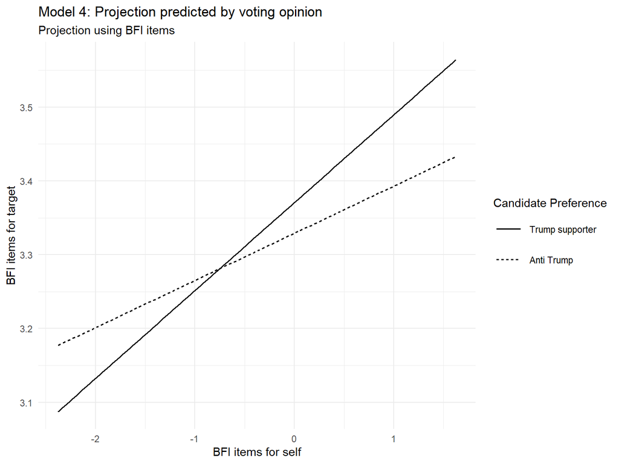

```r
ggplot(mod_opin_bfi_data, aes(selfBFI_c,
                       TargBFI,
                       group = opin_pol_combined,
                       colour = opin_pol_combined)) +
  geom_smooth(method = "lm", se = FALSE, size = .7, colour = "black",
              aes(linetype = opin_pol_combined)) +
  theme_minimal() +
  theme(legend.key.size = unit(1, "cm")) +
  labs(title = "Model 4: Projection predicted by voting opinion",
       subtitle = "Projection using BFI items",
       x = "BFI items for self",
       y = "BFI items for target",
       linetype = "Candidate Preference")
```

## Political knowledge moderator

Does not appear to moderate projection, but does interact with stereotyping of the target.

### With stereotyping

```r
knowledge_mod_data <- EDBFI_overall %>%
  select(sub_id, Targ, stereo_c, group_cond, self_c, house_most_members) %>%
  na.omit() %>%
  mutate(political_knowledge = as.factor(ifelse(house_most_members == 2, "Correct",
                                      ifelse(house_most_members != 2, "Incorrect", NA))))

knowledge_mod <- lmer(Targ ~ self_c*group_cond*stereo_c*political_knowledge + (self_c|sub_id),
               data = knowledge_mod_data)

summary(knowledge_mod)
```

```
## Linear mixed model fit by REML. t-tests use Satterthwaite's method [
## lmerModLmerTest]
## Formula: Targ ~ self_c * group_cond * stereo_c * political_knowledge +
##     (self_c | sub_id)
##    Data: knowledge_mod_data
##
## REML criterion at convergence: 80843.4
##
## Scaled residuals:
##     Min      1Q  Median      3Q     Max
## -3.8242 -0.5866  0.0338  0.6577  3.9639
##
## Random effects:
##  Groups   Name        Variance Std.Dev. Corr
##  sub_id   (Intercept) 0.07916  0.2814
##           self_c      0.05025  0.2242   0.33
##  Residual             0.88674  0.9417
## Number of obs: 29000, groups:  sub_id, 607
##
## Fixed effects:
##                                                                      Estimate
## (Intercept)                                                          3.444427
## self_c                                                               0.099261
## group_condOut-group                                                 -0.249501
## stereo_c                                                             0.402589
## political_knowledgeIncorrect                                         0.012809
## self_c:group_condOut-group                                          -0.108373
## self_c:stereo_c                                                      0.004468
## group_condOut-group:stereo_c                                        -0.027930
## self_c:political_knowledgeIncorrect                                  0.058005
## group_condOut-group:political_knowledgeIncorrect                     0.046105
## stereo_c:political_knowledgeIncorrect                               -0.105077
## self_c:group_condOut-group:stereo_c                                 -0.007292
## self_c:group_condOut-group:political_knowledgeIncorrect             -0.032686
## self_c:stereo_c:political_knowledgeIncorrect                        -0.024195
## group_condOut-group:stereo_c:political_knowledgeIncorrect            0.007712
## self_c:group_condOut-group:stereo_c:political_knowledgeIncorrect     0.019935
##                                                                    Std. Error
## (Intercept)                                                          0.023520
## self_c                                                               0.018734
```

[output cut: 69 more lines]

```
## stereo_c                                                         ***
## political_knowledgeIncorrect
## self_c:group_condOut-group                                       ***
## self_c:stereo_c
## group_condOut-group:stereo_c                                     .
## self_c:political_knowledgeIncorrect                              .
## group_condOut-group:political_knowledgeIncorrect
## stereo_c:political_knowledgeIncorrect                            ***
## self_c:group_condOut-group:stereo_c
## self_c:group_condOut-group:political_knowledgeIncorrect
## self_c:stereo_c:political_knowledgeIncorrect                     .
## group_condOut-group:stereo_c:political_knowledgeIncorrect
## self_c:group_condOut-group:stereo_c:political_knowledgeIncorrect
## ---
## Signif. codes:  0 '***' 0.001 '**' 0.01 '*' 0.05 '.' 0.1 ' ' 1
```

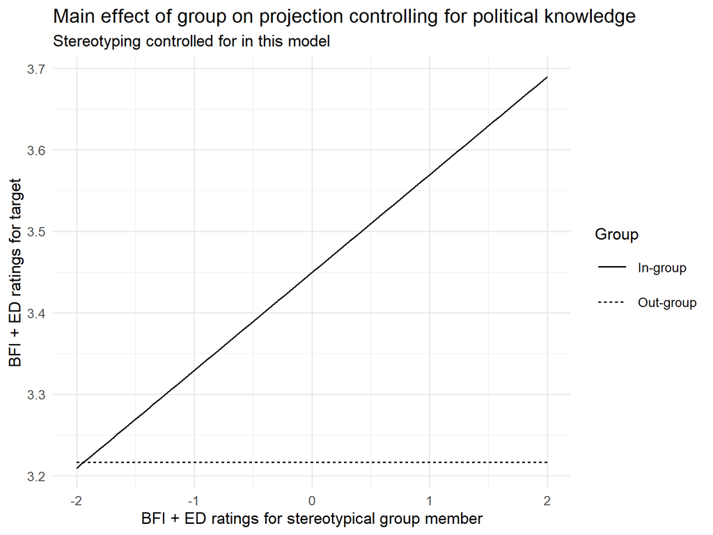

```r
pol_know_stereo_plot <- get_groupME_proj_plot(knowledge_mod)

pol_know_stereo_plot +
  labs(title = "Main effect of group on projection controlling for political knowledge",
       subtitle = "Stereotyping controlled for in this model",
       y = "BFI + ED ratings for target",
       x = "BFI + ED ratings for stereotypical group member",
       linetype = "Group")
```

### Without stereotyping

```r
knowledge_mod_data <- EDBFI_overall %>%
  select(sub_id, Targ, stereo_c, group_cond, self_c, house_most_members) %>%
  na.omit() %>%
  mutate(political_knowledge = as.factor(ifelse(house_most_members == 2, "Correct",
                                      ifelse(house_most_members != 2, "Incorrect", NA))))

knowledge_mod_nostereo <- lmer(Targ ~ self_c*group_cond*political_knowledge + (self_c|sub_id),
               data = knowledge_mod_data)

summary(knowledge_mod_nostereo)
```

```
## Linear mixed model fit by REML. t-tests use Satterthwaite's method [
## lmerModLmerTest]
## Formula: Targ ~ self_c * group_cond * political_knowledge + (self_c |
##     sub_id)
##    Data: knowledge_mod_data
##
## REML criterion at convergence: 84721.6
##
## Scaled residuals:
##     Min      1Q  Median      3Q     Max
## -3.6835 -0.6099  0.0537  0.6748  3.5460
##
## Random effects:
##  Groups   Name        Variance Std.Dev. Corr
##  sub_id   (Intercept) 0.11013  0.3319
##           self_c      0.06834  0.2614   0.36
##  Residual             1.00953  1.0048
## Number of obs: 29000, groups:  sub_id, 607
##
## Fixed effects:
##                                                          Estimate Std. Error
## (Intercept)                                               3.58463    0.02656
## self_c                                                    0.18332    0.02107
## group_condOut-group                                      -0.52071    0.03693
## political_knowledgeIncorrect                             -0.05465    0.04290
## self_c:group_condOut-group                               -0.26195    0.02928
## self_c:political_knowledgeIncorrect                       0.02242    0.03404
## group_condOut-group:political_knowledgeIncorrect          0.18350    0.06173
## self_c:group_condOut-group:political_knowledgeIncorrect   0.03409    0.04901
##                                                                df t value
## (Intercept)                                             602.71111 134.985
## self_c                                                  606.05508   8.702
## group_condOut-group                                     601.78458 -14.101
## political_knowledgeIncorrect                            603.91355  -1.274
## self_c:group_condOut-group                              603.97439  -8.947
## self_c:political_knowledgeIncorrect                     608.33683   0.659
## group_condOut-group:political_knowledgeIncorrect        602.60623   2.973
## self_c:group_condOut-group:political_knowledgeIncorrect 608.42436   0.696
##                                                                     Pr(>|t|)
## (Intercept)                                             < 0.0000000000000002
```

[output cut: 13 more lines]

```
## self_c:political_knowledgeIncorrect
## group_condOut-group:political_knowledgeIncorrect        **
## self_c:group_condOut-group:political_knowledgeIncorrect
## ---
## Signif. codes:  0 '***' 0.001 '**' 0.01 '*' 0.05 '.' 0.1 ' ' 1
##
## Correlation of Fixed Effects:
##             (Intr) self_c grp_O- pltc_I sl_:_O- sl_:_I g_O-:_
## self_c       0.308
## grp_cndOt-g -0.719 -0.221
## pltcl_knwlI -0.619 -0.191  0.445
## slf_c:gr_O- -0.221 -0.720  0.304  0.137
## slf_c:plt_I -0.190 -0.619  0.137  0.304  0.445
## grp_cnO-:_I  0.430  0.132 -0.598 -0.695 -0.182  -0.211
## slf_:_O-:_I  0.132  0.430 -0.182 -0.211 -0.597  -0.695  0.302
```

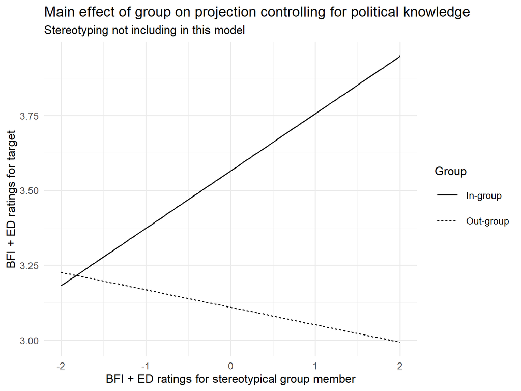

```r
pol_know_nostereo_plot <- get_groupME_proj_plot(knowledge_mod_nostereo)

pol_know_nostereo_plot +
  labs(title = "Main effect of group on projection controlling for political knowledge",
       subtitle = "Stereotyping not including in this model",
       y = "BFI + ED ratings for target",
       x = "BFI + ED ratings for stereotypical group member",
       linetype = "Group")
```

# BFI broken down into facets

## Extraversion

```r
extra_mod_data <- clean_ptcheck %>%
  select(sub_id, BFI_number, TargBFI, selfBFI_c, stereoBFI_c, group_cond,
         identification_c) %>%
  filter(BFI_number == 1 | BFI_number == 6 | BFI_number == 11) %>%
  rename(self_c = selfBFI_c) %>%
  unique() %>%
  na.omit()

contrasts(extra_mod_data$group_cond) <- contr.sum(2)
```

### Results

```r
extra_model <- lmer(TargBFI ~ self_c*group_cond*stereoBFI_c  +
                        + (self_c|sub_id),
               data = extra_mod_data)

summary(extra_model)
```

```
## Linear mixed model fit by REML. t-tests use Satterthwaite's method [
## lmerModLmerTest]
## Formula: TargBFI ~ self_c * group_cond * stereoBFI_c + +(self_c | sub_id)
##    Data: extra_mod_data
##
## REML criterion at convergence: 5232.7
##
## Scaled residuals:
##      Min       1Q   Median       3Q      Max
## -3.03288 -0.58863  0.05935  0.67226  2.37010
##
## Random effects:
##  Groups   Name        Variance Std.Dev. Corr
##  sub_id   (Intercept) 0.13065  0.3614
##           self_c      0.04107  0.2027   0.17
##  Residual             0.82095  0.9061
## Number of obs: 1837, groups:  sub_id, 616
##
## Fixed effects:
##                                   Estimate  Std. Error          df t value
## (Intercept)                       3.280264    0.033335  554.610800  98.402
## self_c                            0.065253    0.023764  652.276318   2.746
## group_cond1                       0.072591    0.033335  554.610800   2.178
## stereoBFI_c                       0.337871    0.027136 1098.923786  12.451
## self_c:group_cond1                0.042445    0.023764  652.276318   1.786
## self_c:stereoBFI_c                0.018948    0.018324 1186.977490   1.034
## group_cond1:stereoBFI_c          -0.026884    0.027136 1098.923786  -0.991
## self_c:group_cond1:stereoBFI_c   -0.007381    0.018324 1186.977491  -0.403
##                                           Pr(>|t|)
## (Intercept)                    <0.0000000000000002 ***
## self_c                                      0.0062 **
## group_cond1                                 0.0299 *
## stereoBFI_c                    <0.0000000000000002 ***
## self_c:group_cond1                          0.0745 .
## self_c:stereoBFI_c                          0.3013
## group_cond1:stereoBFI_c                     0.3220
## self_c:group_cond1:stereoBFI_c              0.6872
## ---
## Signif. codes:  0 '***' 0.001 '**' 0.01 '*' 0.05 '.' 0.1 ' ' 1
##
## Correlation of Fixed Effects:
##             (Intr) self_c grp_c1 stBFI_ sl_:_1 s_:BFI g_1:BF
## self_c       0.487
## group_cond1  0.071  0.081
## stereoBFI_c -0.415 -0.226 -0.137
## slf_c:grp_1  0.081 -0.040  0.487 -0.147
## slf_c:sBFI_ -0.233 -0.414 -0.129  0.495 -0.021
## grp_c1:BFI_ -0.137 -0.147 -0.415  0.280 -0.226  0.160
## sl_:_1:BFI_ -0.129 -0.021 -0.233  0.160 -0.414  0.196  0.495
```

### Plot

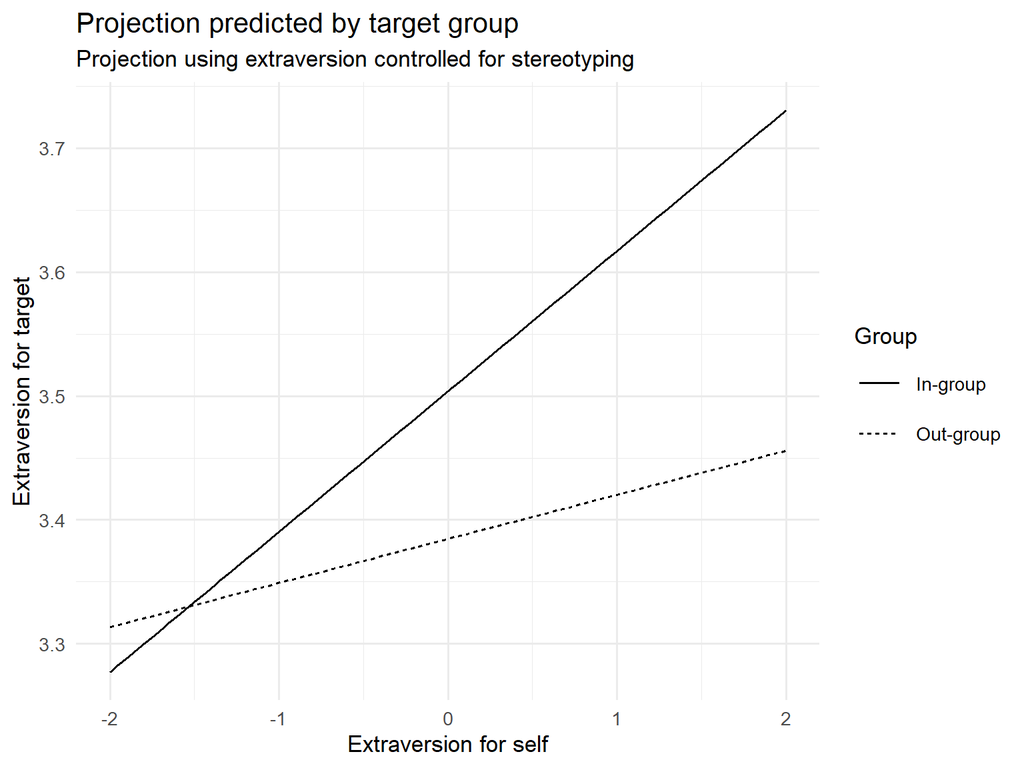

```r
extra_plot <- get_groupME_proj_plot(extra_model)

extra_plot +
  labs(title = "Projection predicted by target group",
       subtitle = "Projection using extraversion controlled for stereotyping",
       x = "Extraversion for self",
       y = "Extraversion for target",
       linetype = "Group")
```

Effect was marginal only

## Agreeableness

```r
agree_mod_data <- clean_ptcheck %>%
  select(sub_id, BFI_number, TargBFI, selfBFI_c, stereoBFI_c, group_cond,
         identification_c) %>%
  filter(BFI_number == 2 | BFI_number == 7 | BFI_number == 12) %>%
  rename(self_c = selfBFI_c) %>%
  unique() %>%
  na.omit()

contrasts(agree_mod_data$group_cond) <- contr.sum(2)
```

### Results

```r
agree_model <- lmer(TargBFI ~ self_c*group_cond*stereoBFI_c  +
                        + (self_c|sub_id),
               data = agree_mod_data)

summary(agree_model)
```

```
## Linear mixed model fit by REML. t-tests use Satterthwaite's method [
## lmerModLmerTest]
## Formula: TargBFI ~ self_c * group_cond * stereoBFI_c + +(self_c | sub_id)
##    Data: agree_mod_data
##
## REML criterion at convergence: 4659.3
##
## Scaled residuals:
##     Min      1Q  Median      3Q     Max
## -3.1886 -0.4925  0.0169  0.5006  4.1155
##
## Random effects:
##  Groups   Name        Variance Std.Dev. Corr
##  sub_id   (Intercept) 0.49957  0.7068
##           self_c      0.03254  0.1804   0.01
##  Residual             0.40543  0.6367
## Number of obs: 1839, groups:  sub_id, 616
##
## Fixed effects:
##                                   Estimate  Std. Error          df t value
## (Intercept)                       3.472408    0.038125  830.468657  91.080
## self_c                            0.137773    0.022814  506.422677   6.039
## group_cond1                       0.361923    0.038125  830.468658   9.493
## stereoBFI_c                       0.315890    0.021771 1729.947544  14.510
## self_c:group_cond1               -0.012018    0.022814  506.422677  -0.527
## self_c:stereoBFI_c                0.009419    0.015261  798.920964   0.617
## group_cond1:stereoBFI_c           0.021851    0.021771 1729.947538   1.004
## self_c:group_cond1:stereoBFI_c   -0.044052    0.015261  798.920963  -2.887
##                                            Pr(>|t|)
## (Intercept)                    < 0.0000000000000002 ***
## self_c                                  0.000000003 ***
## group_cond1                    < 0.0000000000000002 ***
## stereoBFI_c                    < 0.0000000000000002 ***
## self_c:group_cond1                            0.599
## self_c:stereoBFI_c                            0.537
## group_cond1:stereoBFI_c                       0.316
## self_c:group_cond1:stereoBFI_c                0.004 **
## ---
## Signif. codes:  0 '***' 0.001 '**' 0.01 '*' 0.05 '.' 0.1 ' ' 1
##
## Correlation of Fixed Effects:
##             (Intr) self_c grp_c1 stBFI_ sl_:_1 s_:BFI g_1:BF
## self_c      -0.100
## group_cond1 -0.199  0.103
## stereoBFI_c  0.243 -0.160 -0.446
## slf_c:grp_1  0.103 -0.235 -0.100 -0.021
## slf_c:sBFI_ -0.105  0.273  0.011 -0.175 -0.510
## grp_c1:BFI_ -0.446 -0.021  0.243 -0.080 -0.160  0.023
## sl_:_1:BFI_  0.011 -0.510 -0.105  0.023  0.273 -0.063 -0.175
```

### Plot

```r
describe(agree_mod_data$stereoBFI_c)
```

```
##    vars    n  mean   sd median trimmed  mad   min  max range skew kurtosis   se
## X1    1 1839 -0.32 1.33  -0.03   -0.39 1.48 -2.03 1.97     4 0.19    -1.16 0.03
```

```r
agree_effects <- effect(term = "self_c:group_cond:stereoBFI_c",
                           xlevels = list(group_cond = c("In-group",
                                                         "Out-group"),
                                          stereoBFI_c = c(-1.33, 0, 1.33)),
                           mod = agree_model)

agree_effects <- as.data.frame(agree_effects)

agree_effects %<>%
  mutate(Stereotyping = as.factor(stereoBFI_c),
         Stereotyping = dplyr::recode(Stereotyping,
                                      `-1.33` = "Low stereotyping \n (1 SD below)",
                                      `0` = "Average \n stereotyping",
                                      `1.33` = "High stereotyping \n (1 SD above"))
```

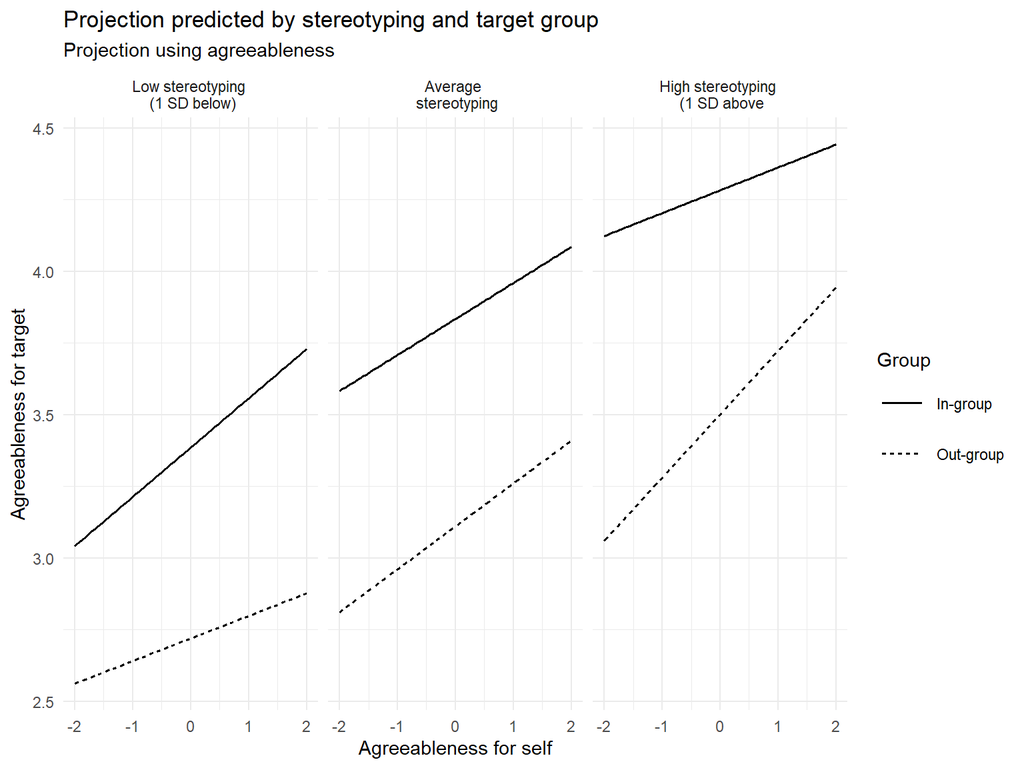

```r
ggplot(agree_effects, aes(self_c,
                                      fit,
                                      group = group_cond,
                                      colour = group_cond)) +
  geom_smooth(method = "lm", se = FALSE, size = .7, colour = "black",
              aes(linetype = group_cond)) +
  facet_wrap(vars(Stereotyping)) +
  theme_minimal() +
  theme(legend.key.size = unit(1, "cm")) +
  labs(title = "Projection predicted by stereotyping and target group",
       subtitle = "Projection using agreeableness",
       x = "Agreeableness for self",
       y = "Agreeableness for target",
       linetype = "Group")
```

## Negative emotion

```r
negemo_data <- clean_ptcheck %>%
  select(sub_id, BFI_number, TargBFI, selfBFI_c, stereoBFI_c, group_cond,
         identification_c) %>%
  filter(BFI_number == 4 | BFI_number == 9 | BFI_number == 14) %>%
  rename(self_c = selfBFI_c) %>%
  unique() %>%
  na.omit()

contrasts(negemo_data$group_cond) <- contr.sum(2)
```

### Results

```r
negemo_model <- lmer(TargBFI ~ self_c*group_cond*stereoBFI_c  +
                        + (self_c|sub_id),
               data = negemo_data)

summary(negemo_model)
```

```
## Linear mixed model fit by REML. t-tests use Satterthwaite's method [
## lmerModLmerTest]
## Formula: TargBFI ~ self_c * group_cond * stereoBFI_c + +(self_c | sub_id)
##    Data: negemo_data
##
## REML criterion at convergence: 5177.2
##
## Scaled residuals:
##     Min      1Q  Median      3Q     Max
## -3.0058 -0.6154 -0.0317  0.5878  3.4621
##
## Random effects:
##  Groups   Name        Variance Std.Dev. Corr
##  sub_id   (Intercept) 0.1660   0.4074
##           self_c      0.0566   0.2379   0.17
##  Residual             0.7439   0.8625
## Number of obs: 1838, groups:  sub_id, 616
##
## Fixed effects:
##                                  Estimate Std. Error         df t value
## (Intercept)                       2.73188    0.02830  582.57980  96.531
## self_c                            0.10767    0.02108  560.19833   5.107
## group_cond1                      -0.12226    0.02830  582.57980  -4.320
## stereoBFI_c                       0.33868    0.02072 1816.64936  16.342
## self_c:group_cond1                0.03133    0.02108  560.19833   1.486
## self_c:stereoBFI_c               -0.01560    0.01466 1427.14890  -1.064
## group_cond1:stereoBFI_c           0.01164    0.02072 1816.64936   0.562
## self_c:group_cond1:stereoBFI_c    0.01738    0.01466 1427.14890   1.186
##                                            Pr(>|t|)
## (Intercept)                    < 0.0000000000000002 ***
## self_c                                   0.00000045 ***
## group_cond1                              0.00001835 ***
## stereoBFI_c                    < 0.0000000000000002 ***
## self_c:group_cond1                            0.138
## self_c:stereoBFI_c                            0.287
## group_cond1:stereoBFI_c                       0.574
## self_c:group_cond1:stereoBFI_c                0.236
## ---
## Signif. codes:  0 '***' 0.001 '**' 0.01 '*' 0.05 '.' 0.1 ' ' 1
##
## Correlation of Fixed Effects:
##             (Intr) self_c grp_c1 stBFI_ sl_:_1 s_:BFI g_1:BF
## self_c       0.138
## group_cond1  0.007  0.005
## stereoBFI_c -0.068 -0.122 -0.002
## slf_c:grp_1  0.005  0.024  0.138 -0.206
## slf_c:sBFI_ -0.095 -0.038 -0.161  0.113  0.044
## grp_c1:BFI_ -0.002 -0.206 -0.068  0.238 -0.122  0.042
## sl_:_1:BFI_ -0.161  0.044 -0.095  0.042 -0.038  0.174  0.113
```

No results with projection

## Open minded

```r
open_data <- clean_ptcheck %>%
  select(sub_id, BFI_number, TargBFI, selfBFI_c, stereoBFI_c, group_cond,
         identification_c) %>%
  filter(BFI_number == 5 | BFI_number == 10 | BFI_number == 15) %>%
  rename(self_c = selfBFI_c) %>%
  unique() %>%
  na.omit()

contrasts(open_data$group_cond) <- contr.sum(2)
```

### Results

```r
open_model <- lmer(TargBFI ~ self_c*group_cond*stereoBFI_c  +
                        + (self_c|sub_id),
               data = open_data)

summary(open_model)
```

```
## Linear mixed model fit by REML. t-tests use Satterthwaite's method [
## lmerModLmerTest]
## Formula: TargBFI ~ self_c * group_cond * stereoBFI_c + +(self_c | sub_id)
##    Data: open_data
##
## REML criterion at convergence: 4763.7
##
## Scaled residuals:
##     Min      1Q  Median      3Q     Max
## -3.9143 -0.5047 -0.0050  0.5026  3.6957
##
## Random effects:
##  Groups   Name        Variance Std.Dev. Corr
##  sub_id   (Intercept) 0.27296  0.5225
##           self_c      0.02708  0.1646   0.22
##  Residual             0.53619  0.7322
## Number of obs: 1836, groups:  sub_id, 616
##
## Fixed effects:
##                                   Estimate  Std. Error          df t value
## (Intercept)                       3.239606    0.032510  663.926503  99.650
## self_c                            0.114446    0.025117  487.813370   4.557
## group_cond1                       0.279072    0.032510  663.926502   8.584
## stereoBFI_c                       0.319105    0.022699 1452.855991  14.058
## self_c:group_cond1                0.027594    0.025117  487.813370   1.099
## self_c:stereoBFI_c                0.021104    0.018066  711.178288   1.168
## group_cond1:stereoBFI_c          -0.004388    0.022699 1452.855991  -0.193
## self_c:group_cond1:stereoBFI_c   -0.051847    0.018066  711.178288  -2.870
##                                            Pr(>|t|)
## (Intercept)                    < 0.0000000000000002 ***
## self_c                                   0.00000658 ***
## group_cond1                    < 0.0000000000000002 ***
## stereoBFI_c                    < 0.0000000000000002 ***
## self_c:group_cond1                          0.27247
## self_c:stereoBFI_c                          0.24313
## group_cond1:stereoBFI_c                     0.84675
## self_c:group_cond1:stereoBFI_c              0.00423 **
## ---
## Signif. codes:  0 '***' 0.001 '**' 0.01 '*' 0.05 '.' 0.1 ' ' 1
##
## Correlation of Fixed Effects:
##             (Intr) self_c grp_c1 stBFI_ sl_:_1 s_:BFI g_1:BF
## self_c      -0.177
## group_cond1  0.007  0.055
## stereoBFI_c -0.078 -0.045 -0.448
## slf_c:grp_1  0.055  0.036 -0.177  0.064
## slf_c:sBFI_ -0.021 -0.091  0.068 -0.276 -0.541
## grp_c1:BFI_ -0.448  0.064 -0.078  0.238 -0.045 -0.033
## sl_:_1:BFI_  0.068 -0.541 -0.021 -0.033 -0.091  0.215 -0.276
```

```r
describe(open_data$stereoBFI_c)
```

```
##    vars    n  mean   sd median trimmed  mad   min  max range  skew kurtosis
## X1    1 1836 -0.02 1.28  -0.03   -0.02 1.48 -2.03 1.97     4 -0.12    -1.06
##      se
## X1 0.03
```

```r
open_effects <- effect(term = "self_c:group_cond:stereoBFI_c",
                           xlevels = list(group_cond = c("In-group",
                                                         "Out-group"),
                                          stereoBFI_c = c(-1.28, 0, 1.28)),
                           mod = open_model)

open_effects <- as.data.frame(open_effects)

open_effects %<>%
  mutate(Stereotyping = as.factor(stereoBFI_c),
         Stereotyping = dplyr::recode(Stereotyping,
                                      `-1.28` = "Low stereotyping \n (1 SD below)",
                                      `0` = "Average \n stereotyping",
                                      `1.28` = "High stereotyping \n (1 SD above"))
```

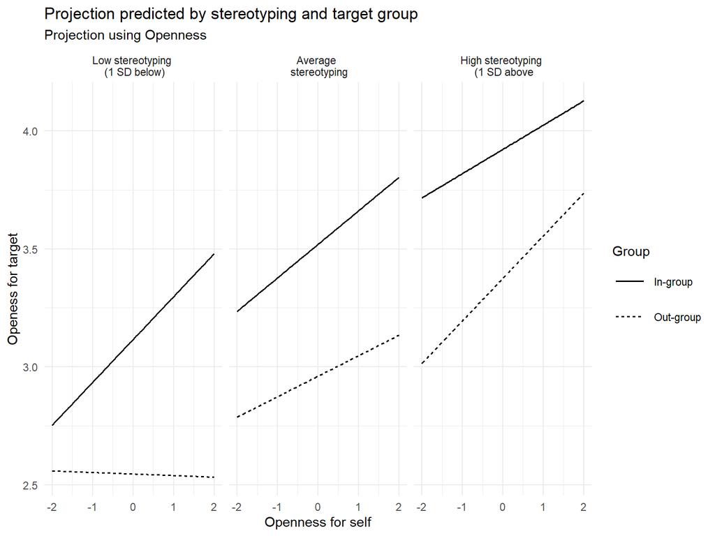

```r
ggplot(open_effects, aes(self_c,
                                      fit,
                                      group = group_cond,
                                      colour = group_cond)) +
  geom_smooth(method = "lm", se = FALSE, size = .7, colour = "black",
              aes(linetype = group_cond)) +
  facet_wrap(vars(Stereotyping)) +
  theme_minimal() +
  theme(legend.key.size = unit(1, "cm")) +
  labs(title = "Projection predicted by stereotyping and target group",
       subtitle = "Projection using Openness",
       x = "Openness for self",
       y = "Openess for target",
       linetype = "Group")
```

## Conscientious

```r
consc_data <- clean_ptcheck %>%
  select(sub_id, BFI_number, TargBFI, selfBFI_c, stereoBFI_c, group_cond,
         identification_c) %>%
  filter(BFI_number == 3 | BFI_number == 8 | BFI_number == 13) %>%
  rename(self_c = selfBFI_c) %>%
  unique() %>%
  na.omit()

contrasts(consc_data$group_cond) <- contr.sum(2)
```

### Results

```r
consc_model <- lmer(TargBFI ~ self_c*group_cond*stereoBFI_c  +
                        + (self_c|sub_id),
               data = consc_data)

summary(consc_model)
```

```
## Linear mixed model fit by REML. t-tests use Satterthwaite's method [
## lmerModLmerTest]
## Formula: TargBFI ~ self_c * group_cond * stereoBFI_c + +(self_c | sub_id)
##    Data: consc_data
##
## REML criterion at convergence: 4704.4
##
## Scaled residuals:
##     Min      1Q  Median      3Q     Max
## -3.5953 -0.4798  0.0715  0.5631  3.3711
##
## Random effects:
##  Groups   Name        Variance Std.Dev. Corr
##  sub_id   (Intercept) 0.321585 0.56708
##           self_c      0.004159 0.06449  -0.38
##  Residual             0.513879 0.71685
## Number of obs: 1840, groups:  sub_id, 616
##
## Fixed effects:
##                                   Estimate  Std. Error          df t value
## (Intercept)                       3.640199    0.030283  679.317693 120.206
## self_c                            0.048038    0.016951  480.430374   2.834
## group_cond1                       0.207457    0.030283  679.317693   6.851
## stereoBFI_c                       0.280453    0.022763 1778.203478  12.321
## self_c:group_cond1                0.049460    0.016951  480.430374   2.918
## self_c:stereoBFI_c                0.021304    0.015335  902.207303   1.389
## group_cond1:stereoBFI_c          -0.015313    0.022763 1778.203477  -0.673
## self_c:group_cond1:stereoBFI_c   -0.005688    0.015335  902.207303  -0.371
##                                            Pr(>|t|)
## (Intercept)                    < 0.0000000000000002 ***
## self_c                                      0.00479 **
## group_cond1                         0.0000000000165 ***
## stereoBFI_c                    < 0.0000000000000002 ***
## self_c:group_cond1                          0.00369 **
## self_c:stereoBFI_c                          0.16512
## group_cond1:stereoBFI_c                     0.50120
## self_c:group_cond1:stereoBFI_c              0.71078
## ---
## Signif. codes:  0 '***' 0.001 '**' 0.01 '*' 0.05 '.' 0.1 ' ' 1
##
## Correlation of Fixed Effects:
##             (Intr) self_c grp_c1 stBFI_ sl_:_1 s_:BFI g_1:BF
## self_c       0.086
## group_cond1  0.075  0.058
## stereoBFI_c -0.149 -0.065 -0.312
## slf_c:grp_1  0.058  0.069  0.086 -0.172
## slf_c:sBFI_ -0.051 -0.144 -0.109 -0.029 -0.311
## grp_c1:BFI_ -0.312 -0.172 -0.149  0.219 -0.065  0.008
## sl_:_1:BFI_ -0.109 -0.311 -0.051  0.008 -0.144  0.138 -0.029
```

### Plot

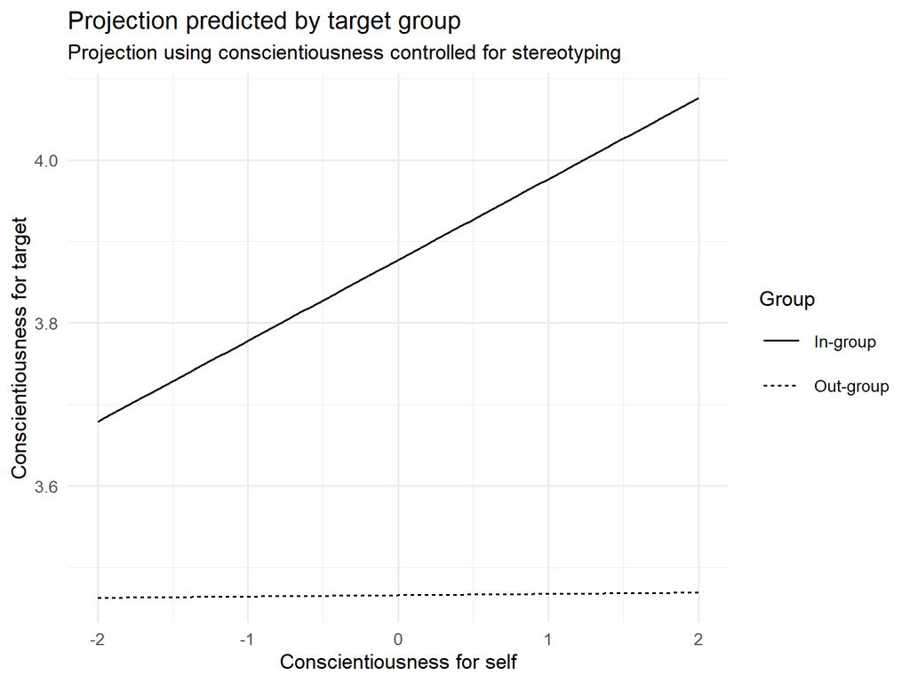

```r
consc_plot <- get_groupME_proj_plot(consc_model)

consc_plot +
  labs(title = "Projection predicted by target group",
       subtitle = "Projection using conscientiousness controlled for stereotyping",
       x = "Conscientiousness for self",
       y = "Conscientiousness for target",
       linetype = "Group")
```

## Honesty/morality

```r
honesty_data <- clean_ptcheck %>%
  select(sub_id, BFI_number, TargBFI, selfBFI_c, stereoBFI_c, group_cond,
         identification_c) %>%
  filter(BFI_number == 16 | BFI_number == 17 | BFI_number == 18 | BFI_number == 19) %>%
  rename(self_c = selfBFI_c) %>%
  unique() %>%
  na.omit()

contrasts(honesty_data$group_cond) <- contr.sum(2)
```

### Results

```r
honesty_model <- lmer(TargBFI ~ self_c*group_cond*stereoBFI_c  +
                        + (self_c|sub_id),
               data = honesty_data)

summary(honesty_model)
```

```
## Linear mixed model fit by REML. t-tests use Satterthwaite's method [
## lmerModLmerTest]
## Formula: TargBFI ~ self_c * group_cond * stereoBFI_c + +(self_c | sub_id)
##    Data: honesty_data
##
## REML criterion at convergence: 6830.5
##
## Scaled residuals:
##     Min      1Q  Median      3Q     Max
## -3.6895 -0.5361  0.0258  0.5909  2.9579
##
## Random effects:
##  Groups   Name        Variance Std.Dev. Corr
##  sub_id   (Intercept) 0.31976  0.5655
##           self_c      0.05392  0.2322   0.00
##  Residual             0.67007  0.8186
## Number of obs: 2450, groups:  sub_id, 616
##
## Fixed effects:
##                                  Estimate Std. Error         df t value
## (Intercept)                       3.56533    0.03090  703.23338 115.368
## self_c                            0.09291    0.02194  620.30715   4.235
## group_cond1                       0.17821    0.03090  703.23339   5.767
## stereoBFI_c                       0.27751    0.01937 2391.29094  14.327
## self_c:group_cond1                0.06265    0.02194  620.30715   2.855
## self_c:stereoBFI_c                0.04128    0.01531 1686.50848   2.696
## group_cond1:stereoBFI_c          -0.03466    0.01937 2391.29094  -1.789
## self_c:group_cond1:stereoBFI_c   -0.00329    0.01531 1686.50848  -0.215
##                                            Pr(>|t|)
## (Intercept)                    < 0.0000000000000002 ***
## self_c                                 0.0000263724 ***
## group_cond1                            0.0000000121 ***
## stereoBFI_c                    < 0.0000000000000002 ***
## self_c:group_cond1                          0.00445 **
## self_c:stereoBFI_c                          0.00708 **
## group_cond1:stereoBFI_c                     0.07372 .
## self_c:group_cond1:stereoBFI_c              0.82988
## ---
## Signif. codes:  0 '***' 0.001 '**' 0.01 '*' 0.05 '.' 0.1 ' ' 1
##
## Correlation of Fixed Effects:
##             (Intr) self_c grp_c1 stBFI_ sl_:_1 s_:BFI g_1:BF
## self_c      -0.089
## group_cond1 -0.080  0.014
## stereoBFI_c  0.140 -0.105 -0.264
## slf_c:grp_1  0.014 -0.104 -0.089 -0.089
## slf_c:sBFI_ -0.061  0.193 -0.053 -0.172 -0.331
## grp_c1:BFI_ -0.264 -0.089  0.140  0.091 -0.105 -0.023
## sl_:_1:BFI_ -0.053 -0.331 -0.061 -0.023  0.193  0.022 -0.172
```

### Plot

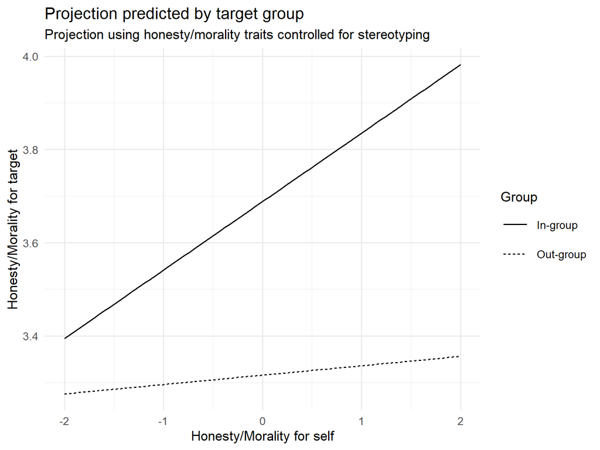

```r
honesty_plot <- get_groupME_proj_plot(honesty_model)

honesty_plot +
  labs(title = "Projection predicted by target group",
       subtitle = "Projection using honesty/morality traits controlled for stereotyping",
       x = "Honesty/Morality for self",
       y = "Honesty/Morality for target",
       linetype = "Group")
```